# Data Science Project

# 1 Q1 - Q4 FFIEC’s Home Mortgage Disclosure Act (HMDA) Loan/Application Register (LAR)

*1. Download the FFIEC’s Home Mortgage Disclosure Act (HMDA) Loan/Application Register (LAR) data for all loans at https://ffiec.cfpb.gov/data-publication/snapshot-national-loan-level-dataset/2021 .*

1. You need the 2021 and 2023 LAR files

*2. Load the data. Please note, if the datafiles do not have column names, you must add as labeled below. A few important points:*

1. The file with the column names can be found at https://ffiec.cfpb.gov/documentation/publications/modified-lar/modified-lar-schema
2. Please also note that the column names or data coding may be in a different order for the two data sets.
3. You will also need to know what the data codes mean- https://ffiec.cfpb.gov/documentation/publications/loan-level-datasets/panel-data-fields
4. To receive full credit, you must read the data in raw from the .csv file and rename the columns in the program in R.
5. Please note, if you read in the first row of data and then rename the column you will lose points. That would delete the first row of real data.

*3. For the national level data, separate your two states from all other data and provide the following comparisons: (no need to exclude DC and other territories, just separate your two states from the rest)*

1. Median loan amount for your states vs. the others
2. Average interest rate for your states vs. the others

*4. State level data* a. Reduce both data files to only the States (using State FIPS code) your group is exploring. b. Append both files into a single data set. c. Format the FIPS county code as 3 digits with leading zeros as necessary.

1. This may be easier to do when reading in the file originally depending on the program you employ.
2. You are welcome to make the data type text if that is the only way you can figure it out.
3. Add a format to loan_amount that puts a comma in for thousands. (Add a dollar sign also for extra credit)

## 1.1 Code Overview

The following R Markdown chunk is set to eval = FALSE because it opens and processes two very large HMDA LAR datasets (approximately 9GB for 2021 and 4GB for 2023), which are very slow to execute within an R Markdown document. Instead, this code was executed directly from the command prompt for efficiency using a script called 01_LARdata.R and the batch command: *R CMD BATCH “%~dp001_LARdata.R”*.

The core of the script is the function process_lar_year(), which takes a year as input and performs a standardized cleaning pipeline for that year’s LAR file. It begins by reading the raw CSV file from the raw_data folder (e.g., raw_data/2021_public_lar.csv), then immediately drops any observations with missing state_code. It keeps only the variables needed for subsequent analysis (such as year, state and county codes, ethnicity, loan characteristics, and occupancy type) to reduce memory usage and focus on relevant fields. It then creates a new indicator variable g3 that flags whether each loan is in Texas or Louisiana (Group 3 states) versus all other states.

Next, the function cleans and standardizes numeric fields and, in particular, the debt-to-income (DTI) ratio. It converts interest_rate and loan_amount to numeric, suppressing warnings that might arise from non-numeric entries. For the DTI variable, it strips out non-numeric characters, extracts the first two digits as a proxy for the minimum DTI, and then assigns each record to an ordered DTI bucket (e.g., <20%, 20%-<30%, up through >60%, plus an Exempt category). This recoded DTI variable is stored as an ordered factor, and the intermediate helper variables used in the transformation are removed to keep the dataset tidy.

The script then converts a number of key variables into labeled factors to make them more interpretable in analysis and reporting. For example, it assigns human-readable labels to action_taken, purchaser_type, loan_type, loan_purpose, reverse_mortgage, open_end_line_of_credit, business_or_commercial_purpose, construction_method, occupancy_type, and the Group 3 indicator g3 itself (with labels “Other States” and “Texas and Louisiana”). It also attaches descriptive variable labels (through the label attribute) to selected columns, so that future tables or exports can use clearer variable descriptions without additional relabeling.

Within each year, the function produces a summary comparison table of Group 3 states versus other states. It groups the data by g3 and calculates the median loan amount and average interest rate for each group. These statistics are then formatted for presentation: loan amounts are shown with a dollar sign and thousands separators, and interest rates are rounded to two decimal places. Column names are replaced with more descriptive titles, and the resulting table is exported as an Excel file to the output directory (e.g., output/comparison_g3vsother_2021.xlsx), preserving a clean, presentation-ready format for reporting. *The resulting tables are included in the next code chunk*

Finally, the function filters the dataset down to only the loans from Texas and Louisiana, pads the county FIPS codes to five digits (ensuring consistent formatting with leading zeros where necessary), and returns this subset. Outside the function, the script calls process_lar_year() separately for 2021 and 2023, binds the two yearly Group 3 datasets together with rbind, and saves the combined result as a Parquet file (proc_data/g3lar.parquet). This final Parquet dataset contains only the cleaned, labeled, and filtered records for Texas and Louisiana across both years, ready for efficient downstream analysis.

```r
###### FUNCTION INITIAL CLEANING ALL STATES ######
process_lar_year <- function(year) {
  # 1. Read in data
  file_path <- sprintf("raw_data/%d_public_lar.csv", year)
  lar <- read.csv(file_path, header = TRUE)

  # 2. Drop missings in state
  lar <- lar[!is.na(lar$state_code), ]

  # 3. Keep only the variables we need
  varstokeep <- c(
    "activity_year", "state_code","county_code",
    "construction_method", "derived_ethnicity",
    "action_taken","purchaser_type", "loan_type","loan_purpose",
    "reverse_mortgage", "open_end_line_of_credit",
    "business_or_commercial_purpose", "loan_amount",
    "interest_rate", "debt_to_income_ratio", "occupancy_type"
  )
  lar <- lar[varstokeep]

  # 4. Create variable that identifies Group 3 states
  lar$g3 <- ifelse(lar$state_code == "TX" | lar$state_code == "LA", 1, 0)

  # 5. Convert Interest Rate and Loan Amount to Numeric
  # and Fix debt to income ratio variable
  lar$interest_rate <- suppressWarnings(as.numeric(lar$interest_rate))
  lar$loan_amount   <- suppressWarnings(as.numeric(lar$loan_amount))

  lar <- lar %>%
    mutate(
      # Step 1: numeric "minimum DTI" using gsub + first 2 digits
      dti_digits = gsub("[^0-9]", "", debt_to_income_ratio),
      dti_min    = suppressWarnings(as.numeric(substr(dti_digits, 1, 2))),

      # Step 2: assign everything (ranges + exact values) into interval buckets
      debt_to_income_ratio = case_when(
        debt_to_income_ratio %in% c("Exempt") ~ "Exempt",
        !is.na(dti_min) & dti_min < 20                ~ "<20%",
        !is.na(dti_min) & dti_min >= 20 & dti_min < 30 ~ "20%-<30%",
        !is.na(dti_min) & dti_min >= 30 & dti_min < 36 ~ "30%-<36%",
        !is.na(dti_min) & dti_min >= 36 & dti_min < 50 ~ "36%-<50%",
        !is.na(dti_min) & dti_min >= 50 & dti_min <= 60 ~ "50%-60%",
        !is.na(dti_min) & dti_min > 60                ~ ">60%",
        TRUE ~ NA_character_
      ),

      # Make it an ordered factor in the desired order
      debt_to_income_ratio = factor(
        debt_to_income_ratio,
        levels = c(
          "<20%",
          "20%-<30%",
          "30%-<36%",
          "36%-<50%",
          "50%-60%",
          ">60%",
          "Exempt"
        ),
        ordered = TRUE
      )
    ) %>%
    select(-dti_digits, -dti_min)

  # 6. Convert to factors and add levels to everything else
  lar <- lar %>%
    mutate(
      #States Group3
      g3 = factor(
        g3,
        levels = c(0,1),
        labels = c(
          "Other States",
          "Texas and Louisiana"
        )
      ),
      # Ethnicity of Applicant or Borrower
      derived_ethnicity = factor(derived_ethnicity),
      # Action Taken
      action_taken = factor(
        action_taken,
        levels = 1:8,
        labels = c(
          "Loan originated",
          "Application approved but not accepted",
          "Application denied",
          "Application withdrawn by applicant",
          "File closed for incompleteness",
          "Purchased loan",
          "Preapproval request denied",
          "Preapproval request approved but not accepted"
        )
      ),
      # Purchaser Type
      purchaser_type = factor(
        purchaser_type,
        levels = c(0, 1, 2, 3, 4, 5, 6, 71, 72, 8, 9),
        labels = c(
          "Not applicable",
          "Fannie Mae",
          "Ginnie Mae",
          "Freddie Mac",
          "Farmer Mac",
          "Private securitizer",
          "Commercial bank savings bank or savings association",
          "Credit union mortgage company or finance company",
          "Life insurance Company",
          "Affiliate institution",
          "Other type of purchaser"
        )
      ),
      # Loan Type
      loan_type = factor(
        loan_type,
        levels = c(1, 2, 3, 4),
        labels = c(
          "Conventional (not insured or guaranteed by FHA VA RHS or FSA)",
          "Federal Housing Administration insured (FHA)",
          "Veterans Affairs guaranteed (VA)",
          "USDA RHS or FSA guaranteed"
        )
      ),
      # Loan Purpose
      loan_purpose = factor(
        loan_purpose,
        levels = c(1, 2, 31, 32, 4, 5),
        labels = c(
          "Home purchase",
          "Home improvement",
          "Refinancing",
          "Cash-out refinancing",
          "Other purpose",
          "Not applicable"
        )
      ),
      # Reverse Mortgage
      reverse_mortgage = factor(
        reverse_mortgage,
        levels = c(1, 2),
        labels = c(
          "Reverse mortgage",
          "Not a reverse mortgage"
        )
      ),
      # Open-End Line of Credit
      open_end_line_of_credit = factor(
        open_end_line_of_credit,
        levels = c(1, 2),
        labels = c(
          "Open-end line of credit",
          "Not an open-end line of credit"
        )
      ),
      # Business or Commercial Purpose
      business_or_commercial_purpose = factor(
        business_or_commercial_purpose,
        levels = c(1, 2),
        labels = c(
          "Primarily for a business or commercial purpose",
          "Not primarily for a business or commercial purpose"
        )
      ),
      # Construction Method
      construction_method = factor(
        construction_method,
        levels = c(1, 2),
        labels = c(
          "Site-built",
          "Manufactured Home"
        )
      ),
      # Occupancy Type
      occupancy_type = factor(
        occupancy_type,
        levels = c(1, 2, 3),
        labels = c(
          "Principal residence",
          "Second residence",
          "Investment property"
        )
      ),
    )

  # 7. Add variable labels
  var_labels <- c(
    activity_year                   = "Year",
    state_code                      = "State 2dig code",
    county_code                     = "County 5dig code",
    derived_ethnicity               = "Ethnicity of Applicant or Borrower",
    action_taken                    = "Action Taken",
    purchaser_type                  = "Type of Purchaser",
    loan_type                       = "Loan Type",
    loan_purpose                    = "Loan Purpose",
    reverse_mortgage                = "Reverse Mortgage",
    open_end_line_of_credit         = "Open-End Line of Credit",
    business_or_commercial_purpose  = "Business or Commercial Purpose",
    loan_amount                     = "Loan Amount",
    interest_rate                   = "Interest Rate",
    debt_to_income_ratio            = "Debt-to-Income Ratio",
    construction_method             = "Construction Method",
    occupancy_type                  = "Occupancy Type",
    g3                              = "Dummy Group 3 States"
  )

  for (v in names(var_labels)) {
    if (v %in% names(lar)) {
      attr(lar[[v]], "label") <- var_labels[[v]]
    }
  }

  # 8. TABLE G3 vs OTHER
  summary_g3vsoth <- lar %>%
    group_by(g3) %>%
    summarise(
      median_loan_amount = median(loan_amount, na.rm = TRUE),
      average_interest_rate = mean(interest_rate, na.rm = TRUE),
      .groups = "drop"
    ) %>%
    # 2. Format for display
    mutate(
      # Dollar sign + commas (no decimals for loan amount, adjust if you want cents)
      median_loan_amount = paste0(
        "$", format(round(median_loan_amount, 0), big.mark = ",", scientific = FALSE)
      ),
      # Interest rate to 2 decimal places
      average_interest_rate = sprintf("%.2f", average_interest_rate)
    )

  # 3. Create a copy with "variable labels" as column names
  summary_g3vsoth_export <- summary_g3vsoth
  names(summary_g3vsoth_export) <- c(
    "Group (G3 vs Other)",
    "Median Loan Amount ($)",
    "Average Interest Rate"
  )

  # 4. Export to Excel
  outname <- sprintf("output/comparison_g3vsother_%d.xlsx", year)
  write.xlsx(summary_g3vsoth_export, file = outname, overwrite = TRUE)
  # 9. FILTER TO ONLY THE STATES WE NEED
  g3lar <- lar %>% filter(g3 == "Texas and Louisiana")

  ##  Small additional cleaning
  # Pad the county code digit to have leading 0ros
  g3lar$county_code <- sprintf("%05d", g3lar$county_code)

  return(g3lar)
}

###### RUN BY YEAR ######

## ---- 2021 ----
g3lar2021 <- process_lar_year(2021)

## ---- 2023 ----
g3lar2023 <- process_lar_year(2023)

###### APPEND 2021 & 2023 ######
g3lar <- rbind(g3lar2021, g3lar2023)

###### SAVE FINAL DATASET ######
write_parquet(g3lar, "proc_data/g3lar.parquet")
```

# 2 Q3: Median loan amount and Average interest rate. TX and LA vs other states

```r
res1 <- read_excel("output/comparison_g3vsother_2021.xlsx")
res2 <- read_excel("output/comparison_g3vsother_2023.xlsx")
kable(res1, format = "markdown", caption = "2021") %>%
  kable_styling(full_width = FALSE)
```

2021

| Group (G3 vs Other) | Median Loan Amount ($) | Average Interest Rate |
| --- | --- | --- |
| Other States | $235,000 | 3.07 |
| Texas and Louisiana | $215,000 | 3.12 |

```r
kable(res2, format = "markdown", caption = "2023") %>%
  kable_styling(full_width = FALSE)
```

2023

| Group (G3 vs Other) | Median Loan Amount ($) | Average Interest Rate |
| --- | --- | --- |
| Other States | $205,000 | 6.94 |
| Texas and Louisiana | $235,000 | 6.64 |

# 3 Q5: Provide the following statistical summaries by each state and year.

*a. Provide a table of minimum, maximum, and average loan amount by loan type.* i. Please make sure that you use the values for loan type and not the numeric codes. (You can use a format or recode the variable , but it should read something like “FHA” not “2”).

```r
#Load data
g3lar = read_parquet("proc_data/g3lar.parquet")

#Structure check
#names(data)
#str(data)

# Q5(a): min, max, mean loan amounts
table_5a <- g3lar %>%
  group_by(state_code, activity_year, loan_type) %>%
  summarise(
    min_loan  = min(loan_amount, na.rm = TRUE),
    max_loan  = max(loan_amount, na.rm = TRUE),
    mean_loan = mean(loan_amount, na.rm = TRUE),
    .groups = "drop"
  ) %>%
  mutate(
    min_loan  = dollar(min_loan, accuracy = 1),
    max_loan  = dollar(max_loan, accuracy = 1),
    mean_loan = dollar(mean_loan, accuracy = 1)
  ) %>%
  rename(
    State                     = state_code,
    Year                      = activity_year,
    `Loan Type`               = loan_type,
    `Minimum Loan Average Amount` = min_loan,
    `Maximum Loan Average Amount` = max_loan,
    `Mean Loan Average Amount`    = mean_loan
  )

kable(
  table_5a,
  format = "markdown",
  caption = "Loan Summary by State, Year, and Loan Type"
) %>%
  kable_styling(full_width = FALSE)
```

Loan Summary by State, Year, and Loan Type

| State | Year | Loan Type | Minimum Loan Average Amount | Maximum Loan Average Amount | Mean Loan Average Amount |
| --- | --- | --- | --- | --- | --- |
| LA | 2021 | Conventional (not insured or guaranteed by FHA VA RHS or FSA) | $5,000 | $144,485,000 | $212,789 |
| LA | 2021 | Federal Housing Administration insured (FHA) | $5,000 | $44,885,000 | $191,929 |
| LA | 2021 | Veterans Affairs guaranteed (VA) | $5,000 | $5,305,000 | $240,017 |
| LA | 2021 | USDA RHS or FSA guaranteed | $5,000 | $5,155,000 | $181,169 |
| LA | 2023 | Conventional (not insured or guaranteed by FHA VA RHS or FSA) | $5,000 | $64,405,000 | $192,384 |
| LA | 2023 | Federal Housing Administration insured (FHA) | $5,000 | $42,115,000 | $210,462 |
| LA | 2023 | Veterans Affairs guaranteed (VA) | $5,000 | $3,005,000 | $265,054 |
| LA | 2023 | USDA RHS or FSA guaranteed | $5,000 | $2,665,000 | $185,034 |
| TX | 2021 | Conventional (not insured or guaranteed by FHA VA RHS or FSA) | $5,000 | $999,995,000 | $289,775 |
| TX | 2021 | Federal Housing Administration insured (FHA) | $5,000 | $57,565,000 | $216,375 |
| TX | 2021 | Veterans Affairs guaranteed (VA) | $5,000 | $9,995,000 | $285,696 |
| TX | 2021 | USDA RHS or FSA guaranteed | $5,000 | $1,485,000 | $212,874 |
| TX | 2023 | Conventional (not insured or guaranteed by FHA VA RHS or FSA) | $5,000 | $993,775,000 | $298,761 |
| TX | 2023 | Federal Housing Administration insured (FHA) | $5,000 | $69,235,000 | $285,811 |
| TX | 2023 | Veterans Affairs guaranteed (VA) | $5,000 | $4,065,000 | $364,239 |
| TX | 2023 | USDA RHS or FSA guaranteed | $5,000 | $3,275,000 | $162,834 |

*b. Provide the same information graphically. Provide a grouped bar chart with the average loan value by loan purpose grouped by state and year. Label the averages for each bar on the chart.* i. Make sure loan type values read with appropriate labels inside the table produced by the software. (You can use a format or recode the variable, but for example 2 should be replaced with “Home improvement” in the table. ii. Do not plot “Not Applicable”. Filter these values out of the graph (but do not remove from main data set).

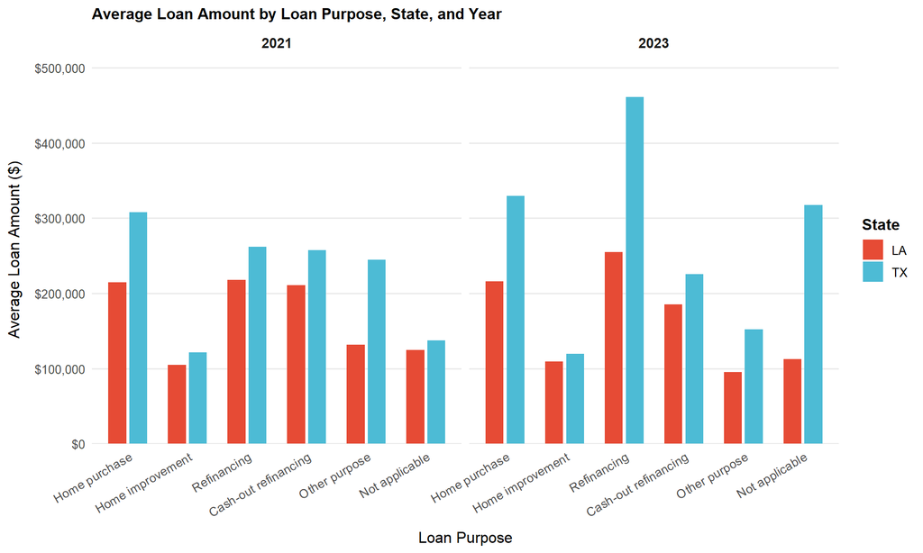

```r
plot_5b_data <- g3lar %>%
  filter(
    !is.na(loan_purpose),
    loan_purpose != "Not Applicable"
  ) %>%
  group_by(state_code, activity_year, loan_purpose) %>%
  summarise(
    avg_loan = mean(loan_amount, na.rm = TRUE),
    .groups = "drop"
  )

ggplot(
  plot_5b_data,
  aes(
    x = loan_purpose,
    y = avg_loan,
    fill = state_code
  )
) +
  geom_col(position = position_dodge(width = 0.7), width = 0.6) +
  facet_wrap(~ activity_year, nrow = 1) +
  scale_fill_manual(
    values = c("LA" = "#E64B35", "TX" = "#4DBBD5"),
    name = "State"
  ) +
  scale_y_continuous(
    labels = dollar_format(accuracy = 1),
    expand = expansion(mult = c(0, 0.12))
  ) +
  labs(
    title = "Average Loan Amount by Loan Purpose, State, and Year",
    x = "Loan Purpose",
    y = "Average Loan Amount ($)"
  ) +
  theme_minimal(base_size = 12) +
  theme(
    plot.title = element_text(face = "bold", size = 12),
    plot.caption = element_text(size = 10, hjust = 0, margin = margin(t = 10)),
    axis.text.x = element_text(angle = 30, hjust = 1, vjust = 1),
    axis.title.x = element_text(margin = margin(t = 10)),
    axis.title.y = element_text(margin = margin(r = 10)),
    panel.grid.major.x = element_blank(),
    panel.grid.minor = element_blank(),
    strip.text = element_text(face = "bold", size = 11),
    legend.position = "right",
    legend.title = element_text(face = "bold")
  )
```

*c. Provide a table of the average value of Interest rate for 2020 and 2022 by property type.* i. Make sure property type is a meaningful label.

```r
table_5c <- g3lar %>%
  filter(activity_year %in% c(2021, 2023)) %>%
  group_by(activity_year, manufactured_home_secured_property_type) %>%
  summarise(
    avg_interest_rate = mean(interest_rate, na.rm = TRUE),
    .groups = "drop"
  ) %>%
  rename(
    Year = activity_year,
    `Property Type` = manufactured_home_secured_property_type,
    `Average Interest Rate` = avg_interest_rate
  )

kable(table_5c,
      format = "markdown",
      caption = "Average Interest Rate by Property Type (2021 & 2023)") %>%
  kable_styling(full_width = FALSE)
```

Average Interest Rate by Property Type (2021 & 2023)

| Year | Property Type | Average Interest Rate |
| --- | --- | --- |
| 2021 | Manufactured home and land | 4.34 |
| 2021 | Manufactured home and not land | 7.35 |
| 2021 | Not applicable | 3.04 |
| 2021 | NA | NaN |
| 2023 | Manufactured home and land | 7.47 |
| 2023 | Manufactured home and not land | 9.35 |
| 2023 | Not applicable | 6.55 |
| 2023 | NA | 5.37 |

*d. Provide a two-way table of the action taken on the loan by derived_ethnicity.* i. Make sure that only the counts are in the table (no percentages, no row or column totals, ONLY counts) ii. Examine the “Not Available” category. What percentage of the data falls into this category? Does it the distribution of missing data look random over the different actions taken on loans?

```r
table_5d <- g3lar %>%
  count(
    `Action Taken` = action_taken,
    Ethnicity = derived_ethnicity,
    name = "Count"
  ) %>%
  # Convert to two-way table
  pivot_wider(
    names_from  = `Action Taken`,
    values_from = Count,
    values_fill = 0
  ) %>%
  # Format numbers with commas
  mutate(across(where(is.numeric), comma))

kable(
  table_5d,
  format  = "markdown",
  caption = "Count of Loans by Action Taken and Ethnicity 2021 & 2023"
) %>%
  kable_styling(full_width = FALSE)
```

Count of Loans by Action Taken and Ethnicity 2021 & 2023

| Ethnicity | Loan originated | Application approved but not accepted | Application denied | Application withdrawn by applicant | File closed for incompleteness | Purchased loan | Preapproval request denied | Preapproval request approved but not accepted |
| --- | --- | --- | --- | --- | --- | --- | --- | --- |
| Ethnicity Not Available | 275,126 | 18,716 | 89,910 | 87,811 | 45,504 | 376,399 | 396 | 1,151 |
| Free Form Text Only | 559 | 31 | 562 | 353 | 77 | 17 | 0 | 0 |
| Hispanic or Latino | 307,543 | 21,600 | 132,458 | 90,379 | 48,414 | 21,167 | 1,900 | 2,095 |
| Joint | 67,237 | 3,225 | 15,805 | 16,827 | 6,369 | 3,450 | 126 | 282 |
| Not Hispanic or Latino | 1,045,225 | 55,579 | 265,387 | 276,016 | 107,624 | 59,820 | 1,385 | 3,796 |

```r
# Q5(d)(ii): Percentage of records with derived_ethnicity
#            = "Ethnicity Not Available"
pct_ethnicity_not_app <- mean(
  g3lar$derived_ethnicity == "Ethnicity Not Available",
  na.rm = TRUE
) * 100

table_5d_ii <- data.frame(
  metric = "Percent with Derived Ethnicity = 'Ethnicity Not Available'",
  percent = round(pct_ethnicity_not_app, 2)
)

kable(table_5d_ii,
      format = "markdown",
      caption = "Percentage of Records with 'Ethnicity Not Available'") %>%
  kable_styling(full_width = FALSE)
```

Percentage of Records with ‘Ethnicity Not Available’

| metric | percent |
| --- | --- |
| Percent with Derived Ethnicity = ‘Ethnicity Not Available’ | 25.9 |

*e. Provide a two-way table of the action taken on the loan by applicant_age.* i. Make sure that only the percentages are in the table (no counts, no row or column totals, ONLY percentages) ii. Make sure Age labels are legible and meaningful. (9999 is not an age.)

```r
data_age <- g3lar %>%
  filter(applicant_age != 8888) %>%        # drop invalid age
  mutate(
    age_group = case_when(
      applicant_age < 25 ~ "<25",
      applicant_age >= 25 & applicant_age <= 34 ~ "25–34",
      applicant_age >= 35 & applicant_age <= 44 ~ "35–44",
      applicant_age >= 45 & applicant_age <= 54 ~ "45–54",
      applicant_age >= 55 & applicant_age <= 64 ~ "55–64",
      applicant_age >= 65 & applicant_age <= 74 ~ "65–74",
      applicant_age >= 75 ~ "75+",
      TRUE ~ NA_character_
    ),
    age_group = factor(
      age_group,
      levels = c("<25", "25–34", "35–44", "45–54", "55–64", "65–74", "75+")
    )
  )

# Long table with percent
table_long <- data_age %>%
  count(action_taken, age_group, name = "n") %>%
  group_by(action_taken) %>%
  mutate(pct = round(100 * n / sum(n), 1)) %>%
  ungroup()

# Convert to two-way table: action_taken rows × age_group columns
table_5e <- table_long %>%
  select(action_taken, age_group, pct) %>%
  tidyr::pivot_wider(
    names_from = age_group,
    values_from = pct
  ) %>%
  rename(`Action Taken` = action_taken)

kable(
  table_5e,
  format = "markdown",
  caption = "Percentage of Applications by Age Group and Action Taken"
) %>%
  kable_styling(full_width = FALSE)
```

Percentage of Applications by Age Group and Action Taken

| Action Taken | <25 | 25–34 | 35–44 | 45–54 | 55–64 | 65–74 | 75+ |
| --- | --- | --- | --- | --- | --- | --- | --- |
| Loan originated | 5.4 | 23.8 | 28.8 | 21.5 | 13.6 | 6.9 | NA |
| Application approved but not accepted | 6.0 | 20.9 | 26.6 | 22.0 | 15.8 | 8.7 | NA |
| Application denied | 7.2 | 19.3 | 26.0 | 22.9 | 16.1 | 8.4 | NA |
| Application withdrawn by applicant | 6.1 | 22.3 | 27.4 | 21.0 | 14.8 | 8.4 | 0 |
| File closed for incompleteness | 6.8 | 20.0 | 26.9 | 21.8 | 15.6 | 8.9 | 0 |
| Purchased loan | 6.0 | 32.3 | 29.4 | 17.9 | 10.0 | 4.4 | NA |
| Preapproval request denied | 8.7 | 32.5 | 30.9 | 16.9 | 7.9 | 3.1 | NA |
| Preapproval request approved but not accepted | 6.1 | 30.6 | 29.8 | 17.6 | 10.8 | 5.1 | NA |

# 4 Q6 Provide the following statistical summaries.

*a. Provide a table of minimum, maximum, and average loan value by loan type.* i. Please make sure that you use the values for loan type and not the numeric codes. (You can use a format or recode the variable , but it should read something like FHA not “2”).

```r
g3lar$loan_type_label <- recode(g3lar$loan_type,
                                "1" = "Conventional",
                                "2" = "FHA",
                                "3" = "VA",
                                "4" = "USDA")

table_6a <- g3lar %>%
  group_by(loan_type_label) %>%
  summarize(
    min_value  = min(loan_amount, na.rm = TRUE),
    max_value  = max(loan_amount, na.rm = TRUE),
    mean_value = mean(loan_amount, na.rm = TRUE)
  ) %>%
  mutate(
    min_value  = dollar(min_value),
    max_value  = dollar(max_value),
    mean_value = dollar(round(mean_value, 0))
  ) %>%
  rename(
    `Loan Type`               = loan_type_label,
    `Minimum Loan Average Amount` = min_value,
    `Maximum Loan Average Amount` = max_value,
    `Mean Loan Average Amount`    = mean_value
  )


kable(table_6a,
      format = "markdown",
      caption = "Loan Amount Summary by Loan Type") %>%
  kable_styling(full_width = FALSE)
```

Loan Amount Summary by Loan Type

| Loan Type | Minimum Loan Average Amount | Maximum Loan Average Amount | Mean Loan Average Amount |
| --- | --- | --- | --- |
| Conventional (not insured or guaranteed by FHA VA RHS or FSA) | $5,000 | $999,995,000 | $283,304 |
| Federal Housing Administration insured (FHA) | $5,000 | $69,235,000 | $236,299 |
| Veterans Affairs guaranteed (VA) | $5,000 | $9,995,000 | $302,614 |
| USDA RHS or FSA guaranteed | $5,000 | $5,155,000 | $188,682 |

No N/A results were found, so those categories were excluded from the final two-way table.

*b. Provide similar information graphically. Provide a grouped bar chart with the average loan value by loan type grouped by state and year.* i. Label the averages for each bar on the chart.

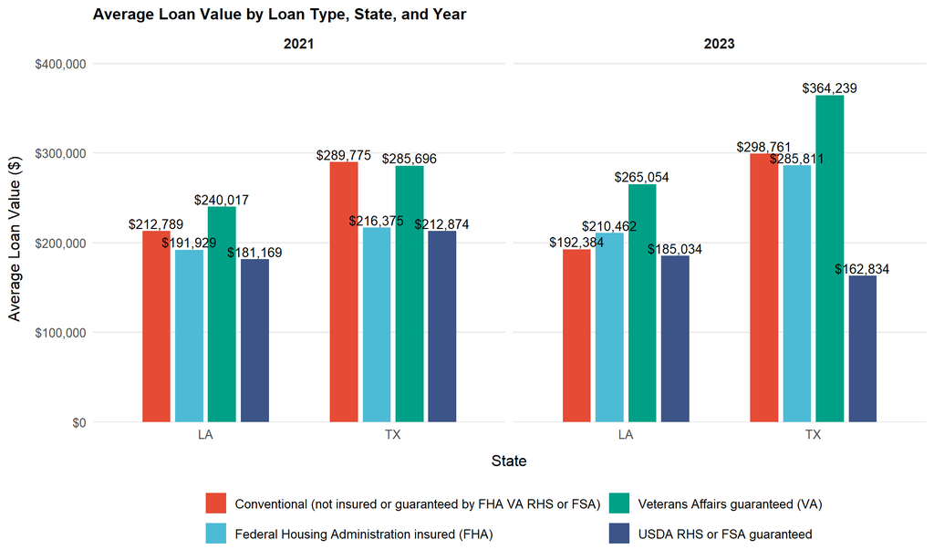

```r
avg_plot_data <- g3lar %>%
  group_by(state_code, activity_year, loan_type_label) %>%
  summarize(avg_value = mean(loan_amount, na.rm = TRUE))

loan_types <- sort(unique(avg_plot_data$loan_type_label))
palette_colors <- c("#E64B35", "#4DBBD5", "#00A087", "#3C5488")
palette_colors <- rep(palette_colors, length.out = length(loan_types))
loan_colors <- setNames(palette_colors, loan_types)

ggplot(
  avg_plot_data,
  aes(
    x = state_code,
    y = avg_value,
    fill = loan_type_label
  )
) +
  geom_col(
    position = position_dodge(width = 0.7),
    width = 0.6
  ) +
  geom_text(
    aes(label = dollar(avg_value, accuracy = 1)),
    position = position_dodge(width = 0.7),
    vjust = -0.25,
    size = 3.5
  ) +

  facet_wrap(~ activity_year, nrow = 1) +
  scale_fill_manual(
    values = loan_colors,
    name=""
  ) +

  scale_y_continuous(
    labels = dollar_format(accuracy = 1),
    expand = expansion(mult = c(0, 0.12))
  ) +

  labs(
    title = "Average Loan Value by Loan Type, State, and Year",
    x = "State",
    y = "Average Loan Value ($)"
  ) +

  theme_minimal(base_size = 12) +
  theme(
    plot.title   = element_text(face = "bold", size = 12),
    plot.caption = element_text(size = 10, hjust = 0, margin = margin(t = 10)),

    axis.text.x  = element_text(angle = 0, hjust = 0.5, vjust = 1),
    axis.title.x = element_text(margin = margin(t = 10)),
    axis.title.y = element_text(margin = margin(r = 10)),

    panel.grid.major.x = element_blank(),
    panel.grid.minor   = element_blank(),

    strip.text = element_text(face = "bold", size = 11),

    legend.position = "bottom",
    legend.title = element_text(face = "bold"),
    legend.box = "horizontal"
    ) +
  guides(fill = guide_legend(ncol = 2)) +
  scale_x_discrete(labels = function(x) str_wrap(x, width = 5))
```

*c. Provide a table of the average value of loans for 2023 and 2021 by property type.* i. Make sure loan type values read with appropriate labels inside the table produced by the software. (You can use a format or recode the variable, but for example 2 should be replaced with “Manufactured housing” in the table.

```r
g3lar$property_type <- recode(g3lar$manufactured_home_secured_property_type,
                                 "1" = "Site-built",
                                 "2" = "Manufactured housing",
                              "Not appliacble" = "Not applicable")

# Replace NA with "Not applicable"
g3lar$property_type[is.na(g3lar$property_type)] <- "Not applicable"


table_6c <- g3lar %>%
  group_by(activity_year, property_type) %>%
  summarize(
    avg_value = mean(loan_amount, na.rm = TRUE),
    .groups = "drop"
  ) %>%
  mutate(
    avg_value = dollar(round(avg_value, 0))   # add commas + $ + rounding
  ) %>%
  rename(
    Year = activity_year,
    `Property Type` = property_type,
    `Loan Average Amount` = avg_value
  )

kable(table_6c,
      format = "markdown",
      caption = "Average Loan Amount by Year and Manufactured Home Secured Property Type") %>%
  kable_styling(full_width = FALSE)
```

Average Loan Amount by Year and Manufactured Home Secured Property Type

| Year | Property Type | Loan Average Amount |
| --- | --- | --- |
| 2021 | Manufactured home and land | $149,936 |
| 2021 | Manufactured home and not land | $89,026 |
| 2021 | Not applicable | $278,756 |
| 2023 | Manufactured home and land | $166,953 |
| 2023 | Manufactured home and not land | $107,468 |
| 2023 | Not applicable | $309,634 |

*d. Provide a two-way table of the action taken on the loan by occupancy type.* i. Make sure that only the counts are in the table (no percentages, no row or column totals, ONLY counts). ii. Examine the “Not Applicable” category. What percentage of the data falls into this category? iii. Choose an appropriate graph to represent the data in this table.

```r
tab_6d <- table(
  action_taken   = g3lar$action_taken,
  occupancy_type = g3lar$occupancy_type,
  useNA = "ifany"
)

# Fix any empty or NA column names so every column has a valid name
cn <- colnames(tab_6d)
cn[cn == "" | is.na(cn)] <- "Missing / blank"
colnames(tab_6d) <- cn

# Convert to data frame for kable
tab_6d_df_mat <- as.data.frame.matrix(tab_6d)

table_6d_df <- data.frame(
  action_taken = rownames(tab_6d_df_mat),
  tab_6d_df_mat,
  row.names = NULL,
  check.names = FALSE
) %>%
  rename(`Action Taken` = action_taken)

table_6d_df_formatted <- table_6d_df %>%
  mutate(across(
    .cols = where(is.numeric),
    .fns  = ~ format(.x, big.mark = ",", scientific = FALSE)
  ))

kable(
  table_6d_df_formatted,
  format = "markdown",
  caption = "Cross-Tabulation of Action Taken by Occupancy Type (Counts Only)"
) %>%
  kable_styling(full_width = FALSE)
```

Cross-Tabulation of Action Taken by Occupancy Type (Counts Only)

| Action Taken | Principal residence | Second residence | Investment property |
| --- | --- | --- | --- |
| Loan originated | 1,522,649 | 28,565 | 144,476 |
| Application approved but not accepted | 90,295 | 1,643 | 7,213 |
| Application denied | 471,100 | 7,864 | 25,158 |
| Application withdrawn by applicant | 425,101 | 9,066 | 37,219 |
| File closed for incompleteness | 195,946 | 2,664 | 9,378 |
| Purchased loan | 434,748 | 5,443 | 20,662 |
| Preapproval request denied | 3,633 | 65 | 109 |
| Preapproval request approved but not accepted | 6,837 | 194 | 293 |

```r
# 2. Percentage of data in "Not Applicable" action_taken
percent_not_applicable <- mean(g3lar$action_taken == "Not Applicable", na.rm = TRUE)
```

*The percentage of data in “Not Applicable” for action taken is 0*

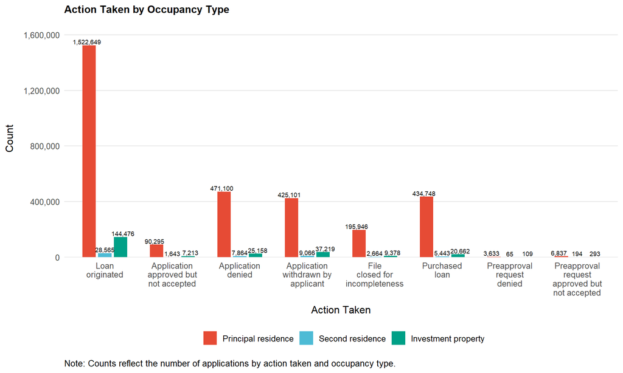

```r
# 1. Collapse data first (for speed)
action_plot_data <- g3lar %>%
  count(action_taken, occupancy_type, name = "n")

# 2. Build a dynamic, safe color mapping like in your avg_plot_data plot
occ_types <- sort(unique(action_plot_data$occupancy_type))
palette_colors <- c("#E64B35", "#4DBBD5", "#00A087", "#3C5488")
palette_colors <- rep(palette_colors, length.out = length(occ_types))
occ_colors <- setNames(palette_colors, occ_types)

# 3. Plot in the same style as your reference code
ggplot(
  action_plot_data,
  aes(
    x = action_taken,
    y = n,
    fill = occupancy_type
  )
) +
  geom_col(
    position = position_dodge(width = 0.7),
    width = 0.6
  ) +
  geom_text(
    aes(label = comma(n)),
    position = position_dodge(width = 0.8),
    vjust = -0.25,
    hjust = 0.5,
    size = 2.5,
    color = "black"
  ) +
  scale_fill_manual(
    values = occ_colors,
    name = ""
  ) +

  scale_y_continuous(
    labels = comma,
    expand = expansion(mult = c(0, 0.12))
  ) +

  labs(
    title = "Action Taken by Occupancy Type",
    x = "Action Taken",
    y = "Count",
    caption = "Note: Counts reflect the number of applications by action taken and occupancy type."
  ) +

  theme_minimal(base_size = 12) +
  theme(
    plot.title   = element_text(face = "bold", size = 12),
    plot.caption = element_text(size = 10, hjust = 0, margin = margin(t = 10)),

    axis.text.x  = element_text(angle = 0, hjust = 0.5, vjust = 1),
    axis.title.x = element_text(margin = margin(t = 10)),
    axis.title.y = element_text(margin = margin(r = 10)),

    panel.grid.major.x = element_blank(),
    panel.grid.minor   = element_blank(),

    strip.text = element_text(face = "bold", size = 11),

    legend.position = "bottom",
    legend.title    = element_text(face = "bold")
  ) +
  guides(fill = guide_legend(ncol = 3)) +
  scale_x_discrete(labels = function(x) str_wrap(x, width = 12))
```

The “Action Taken by Occupancy” graph was difficult to interpret, so we provided individual plots for each occupancy type to make the information clearer. Because the values varied significantly across categories, some variables were hard to distinguish in the combined bar chart. To improve readability and comparison, we added separate bar charts for each occupancy type.

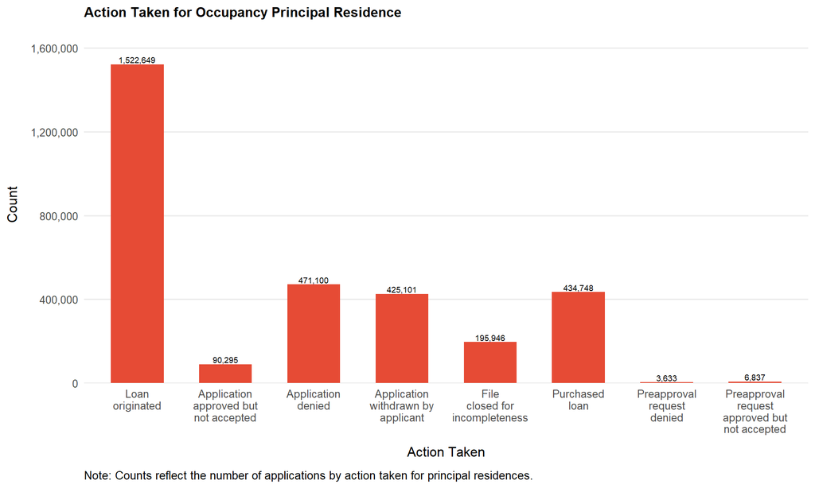

```r
# Filtered, pre-collapsed data for each occupancy type
principal_data <- action_plot_data %>%
  filter(occupancy_type == "Principal residence")

second_data <- action_plot_data %>%
  filter(occupancy_type == "Second residence")

investment_data <- action_plot_data %>%
  filter(occupancy_type == "Investment property")

## 1. Principal residence
ggplot(
  principal_data,
  aes(x = action_taken, y = n)
) +
  geom_col(
    fill = occ_colors["Principal residence"],
    width = 0.6
  ) +
  geom_text(
    aes(label = comma(n)),
    vjust = -0.25,
    size = 2.5,
    color = "black"
  ) +
  scale_y_continuous(
    labels = comma,
    expand = expansion(mult = c(0, 0.12))
  ) +
  scale_x_discrete(labels = function(x) str_wrap(x, width = 12)) +
  labs(
    title   = "Action Taken for Occupancy Principal Residence",
    x       = "Action Taken",
    y       = "Count",
    caption = "Note: Counts reflect the number of applications by action taken for principal residences."
  ) +
  theme_minimal(base_size = 12) +
  theme(
    plot.title   = element_text(face = "bold", size = 12),
    plot.caption = element_text(size = 10, hjust = 0, margin = margin(t = 10)),

    axis.text.x  = element_text(angle = 0, hjust = 0.5, vjust = 1),
    axis.title.x = element_text(margin = margin(t = 10)),
    axis.title.y = element_text(margin = margin(r = 10)),

    panel.grid.major.x = element_blank(),
    panel.grid.minor   = element_blank()
  )
```

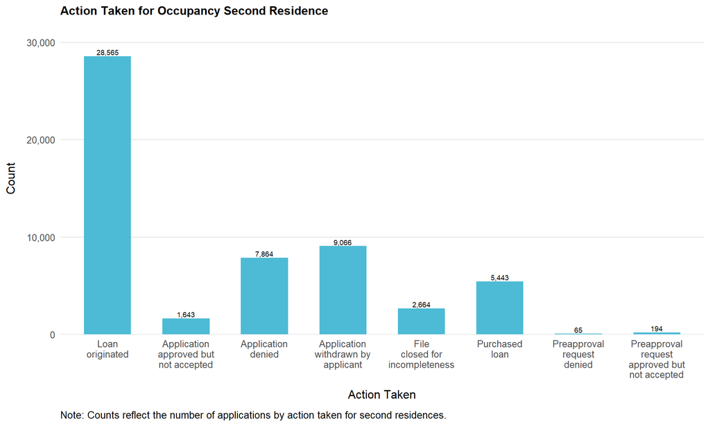

```r
## 2. Second residence
ggplot(
  second_data,
  aes(x = action_taken, y = n)
) +
  geom_col(
    fill = occ_colors["Second residence"],
    width = 0.6
  ) +
  geom_text(
    aes(label = comma(n)),
    vjust = -0.25,
    size = 2.5,
    color = "black"
  ) +
  scale_y_continuous(
    labels = comma,
    expand = expansion(mult = c(0, 0.12))
  ) +
  scale_x_discrete(labels = function(x) str_wrap(x, width = 12)) +
  labs(
    title   = "Action Taken for Occupancy Second Residence",
    x       = "Action Taken",
    y       = "Count",
    caption = "Note: Counts reflect the number of applications by action taken for second residences."
  ) +
  theme_minimal(base_size = 12) +
  theme(
    plot.title   = element_text(face = "bold", size = 12),
    plot.caption = element_text(size = 10, hjust = 0, margin = margin(t = 10)),

    axis.text.x  = element_text(angle = 0, hjust = 0.5, vjust = 1),
    axis.title.x = element_text(margin = margin(t = 10)),
    axis.title.y = element_text(margin = margin(r = 10)),

    panel.grid.major.x = element_blank(),
    panel.grid.minor   = element_blank()
  )
```

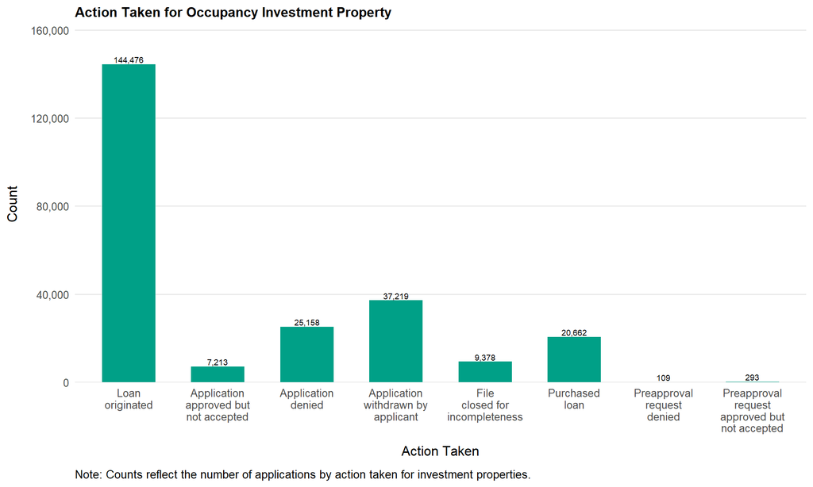

```r
## 3. Investment property
ggplot(
  investment_data,
  aes(x = action_taken, y = n)
) +
  geom_col(
    fill = occ_colors["Investment property"],
    width = 0.6
  ) +
  geom_text(
    aes(label = comma(n)),
    vjust = -0.25,
    size = 2.5,
    color = "black"
  ) +
  scale_y_continuous(
    labels = comma,
    expand = expansion(mult = c(0, 0.12))
  ) +
  scale_x_discrete(labels = function(x) str_wrap(x, width = 12)) +
  labs(
    title   = "Action Taken for Occupancy Investment Property",
    x       = "Action Taken",
    y       = "Count",
    caption = "Note: Counts reflect the number of applications by action taken for investment properties."
  ) +
  theme_minimal(base_size = 12) +
  theme(
    plot.title   = element_text(face = "bold", size = 12),
    plot.caption = element_text(size = 10, hjust = 0, margin = margin(t = 10)),

    axis.text.x  = element_text(angle = 0, hjust = 0.5, vjust = 1),
    axis.title.x = element_text(margin = margin(t = 10)),
    axis.title.y = element_text(margin = margin(r = 10)),

    panel.grid.major.x = element_blank(),
    panel.grid.minor   = element_blank()
  )
```

# 5 Q7. Do the following without creating a new dataset (i.e. filter the data): Based on summary statistics, is there any difference in the rates of “open-end_line_of_credit” by “derived_ethnicity” after applying the following filters:

*a. Loan type is equal to “Conventional”* *b. Occupancy Type is equal to “Principal residence”* *c. Loan Purpose is equal to “Home purchase”* *d. Reverse Mortgage is “Not a reverse mortgage”*

We disagree with the suggestion of “without creating a new dataset” as the dataset is needed for future steps and overwriting it would imply that we would need to read it again later, a process that is inefficient. For that reason we created a new dataset with the filtered parameters.

```r
q7_data <- g3lar %>%
  filter(
    loan_type == "Conventional (not insured or guaranteed by FHA VA RHS or FSA)",
    occupancy_type == "Principal residence",
    loan_purpose == "Home purchase",
    reverse_mortgage == "Not a reverse mortgage"
  )

# Check how many observations left after filtering
cat("Observations left after filtering")
```

```
## Observations left after filtering
```

```r
nrow(q7_data)
```

```
## [1] 1064785
```

```r
# Check how many in each ethnicity group
cat("Tabulation of Ethnicity Group")
```

```
## Tabulation of Ethnicity Group
```

```r
table(q7_data$derived_ethnicity, useNA = "ifany")
```

```
##
## Ethnicity Not Available     Free Form Text Only      Hispanic or Latino
##                  246707                     319                  203893
##                   Joint  Not Hispanic or Latino
##                   36204                  577662
```

```r
# 2) Compute rate of open-end line of credit by ethnicity
q7_summary <- q7_data %>%
  group_by(derived_ethnicity) %>%
  summarize(
    n_obs   = n(),
    n_open  = sum(open_end_line_of_credit == "Open-end line of credit",
                  na.rm = TRUE),
    rate_open = n_open / n_obs,
    .groups = "drop"
  ) %>%
  # readable labels (adjust if your raw values differ)
  mutate(
    derived_ethnicity_label = recode(
      derived_ethnicity,
      "Hispanic or Latino"              = "Hispanic or Latino",
      "Not Hispanic or Latino"          = "Not Hispanic or Latino",
      "Ethnicity Not Available"         = "Ethnicity Not Available",
      "Joint"                           = "Joint",
      "Free Form Text Only"             = "Free-form Text Only",
      .default                          = as.character(derived_ethnicity)
    ),
    n_obs   = comma(n_obs),
    n_open  = comma(n_open),
    rate_open = percent(rate_open, accuracy = 0.1)
  ) %>%
  select(
    `Derived Ethnicity` = derived_ethnicity_label,
    `Number of Loans` = n_obs,
    `Number Open-End LOC` = n_open,
    `Share Open-End LOC` = rate_open
  )

kable(q7_summary,
      format = "markdown",
      caption = "Open-End Lines of Credit by Derived Ethnicity") %>%
  kable_styling(full_width = FALSE)
```

Open-End Lines of Credit by Derived Ethnicity

| Derived Ethnicity | Number of Loans | Number Open-End LOC | Share Open-End LOC |
| --- | --- | --- | --- |
| Ethnicity Not Available | 246,707 | 914 | 0.4% |
| Free-form Text Only | 319 | 17 | 5.3% |
| Hispanic or Latino | 203,893 | 1,368 | 0.7% |
| Joint | 36,204 | 258 | 0.7% |
| Not Hispanic or Latino | 577,662 | 4,320 | 0.7% |

# 6 Q8. Create a new dataset that is summary statistics by year, state, and county. It should include:

*a. Average interest rate per county.* *b. Percentage of “actions taken” for loan origination (versus all other values).* *c. Percentage of debt_to_income_ratio that are less than 45%* i. This one will require recoding because of ranges. Suggest using gsub to remove punctuation and then take the first two characters and make them a new variable. But we want the lowest percent for each one, you cannot just set the ranges to missing. *d. Percentage of loans that are for Freddie Mac (Type of Purchaser)* *e. Percentage of loans that are “business or commercial purpose”*

```r
# Create helper indicators for Q8
lar_q8 <- g3lar %>%
  mutate(

    # (b) Loan origination indicator
    is_origination = case_when(
      action_taken == "Loan originated" ~ 1,
      TRUE ~ 0
    ),

    # (c) Debt-to-income: extract lowest value in the range
    dti_str = as.character(debt_to_income_ratio),
    dti_clean = gsub("[^0-9]", "", dti_str),
    dti_low = suppressWarnings(as.numeric(substr(dti_clean, 1, 2))),
    dti_lt_45 = ifelse(!is.na(dti_low) & dti_low < 45, 1, 0),

    # (d) Freddie Mac indicator – Purchaser Type
    is_freddie = case_when(
      purchaser_type == "Freddie Mac" ~ 1,
      TRUE ~ 0
    ),

    # (e) Business or commercial purpose indicator
    is_business = case_when(
      business_or_commercial_purpose == 1 ~ 1,
      business_or_commercial_purpose == "Business or commercial purpose" ~ 1,
      TRUE ~ 0
    )
  )

# Create summary dataset by year, state, county
q8_summary <- lar_q8 %>%
  group_by(activity_year, state_code, county_code) %>%
  summarize(
    avg_interest_rate = mean(interest_rate, na.rm = TRUE), #Average interest rate per county
    pct_origination = mean(is_origination, na.rm = TRUE), #Percentage of “actions taken” for loan origination (versus all other values)
    pct_dti_under_45 = mean(dti_lt_45, na.rm = TRUE), #Percentage of debt_to_income_ratio that are less than 45%***
    pct_freddie = mean(is_freddie, na.rm = TRUE), # Percentage of loans that are for Freddie Mac (Type of Purchaser)
    pct_business = mean(is_business, na.rm = TRUE),
    .groups = "drop" #Percentage of loans that are “business or commercial purpose
  )

q8_summary_fmt <- q8_summary %>%
  mutate(
    avg_interest_rate = round(avg_interest_rate, 3),  # keep as numeric (not %)
    pct_origination   = percent(pct_origination,   accuracy = 0.1),
    pct_dti_under_45  = percent(pct_dti_under_45,  accuracy = 0.1),
    pct_freddie       = percent(pct_freddie,       accuracy = 0.1),
    pct_business      = percent(pct_business,      accuracy = 0.1)
  ) %>%
  arrange(activity_year, state_code, county_code) %>%
  rename(
    `Year`                      = activity_year,
    `State`                     = state_code,
    `County`                    = county_code,
    `Avg. Interest Rate`        = avg_interest_rate,
    `% Loan Originations`       = pct_origination,
    `% DTI < 45%`               = pct_dti_under_45,
    `% Freddie Mac Purchases`   = pct_freddie,
    `% Business Purpose Loans`  = pct_business
  )
q8_summary_fmt_10 <- q8_summary_fmt %>%
  slice(1:10)

kable(q8_summary_fmt_10,
      format = "markdown",
      caption = "Summary of Loan Characteristics by Year, State, and County \n (First 10 Rows)") %>%
  kable_styling(full_width = FALSE)
```

Summary of Loan Characteristics by Year, State, and County (First 10 Rows)

| Year | State | County | Avg. Interest Rate | % Loan Originations | % DTI < 45% | % Freddie Mac Purchases | % Business Purpose Loans |
| --- | --- | --- | --- | --- | --- | --- | --- |
| 2021 | LA | NA | 5.31 | 8.2% | 33.0% | 0.1% | 0.0% |
| 2021 | LA | 22001 | 3.66 | 52.1% | 57.1% | 9.9% | 0.0% |
| 2021 | LA | 22003 | 4.06 | 45.9% | 53.1% | 5.8% | 0.0% |
| 2021 | LA | 22005 | 3.08 | 55.7% | 53.2% | 14.1% | 0.0% |
| 2021 | LA | 22007 | 3.32 | 45.9% | 51.2% | 9.2% | 0.0% |
| 2021 | LA | 22009 | 3.31 | 51.7% | 43.2% | 9.5% | 0.0% |
| 2021 | LA | 22011 | 3.57 | 50.4% | 42.7% | 7.0% | 0.0% |
| 2021 | LA | 22013 | 4.55 | 34.3% | 41.7% | 3.5% | 0.0% |
| 2021 | LA | 22015 | 2.98 | 52.5% | 40.6% | 8.4% | 0.0% |
| 2021 | LA | 22017 | 3.12 | 49.6% | 42.0% | 8.9% | 0.0% |

```r
#### SUMMARY of the new DATA
# Select numeric columns for descriptive stats
q8_desc <- q8_summary %>%
  select(
    avg_interest_rate,
    pct_origination,
    pct_dti_under_45,
    pct_freddie,
    pct_business
  )

# Compute descriptive statistics
desc_table <- psych::describe(q8_desc) %>%
  as.data.frame() %>%
  rownames_to_column("variable") %>%
  mutate(
    variable = recode(variable,
                      avg_interest_rate = "Avg. Interest Rate",
                      pct_origination   = "% Loan Originations",
                      pct_dti_under_45  = "% DTI < 45%",
                      pct_freddie       = "% Freddie Mac Purchases",
                      pct_business      = "% Business Purpose Loans"),
    across(c(mean, sd, median, min, max), ~ round(.x, 4))
  ) %>%
  select(variable, n, mean, sd, median, min, max)

kable(desc_table,
      format = "markdown",
      caption = "Descriptive Statistics for Summary statistics by year, state, and county") %>%
  kable_styling(full_width = FALSE)
```

Descriptive Statistics for Summary statistics by year, state, and county

| variable | n | mean | sd | median | min | max |
| --- | --- | --- | --- | --- | --- | --- |
| Avg. Interest Rate | 639 | 5.304 | 1.839 | 5.957 | 2.5 | 8.81 |
| % Loan Originations | 640 | 0.433 | 0.086 | 0.444 | 0.0 | 1.00 |
| % DTI < 45% | 640 | 0.476 | 0.070 | 0.473 | 0.2 | 1.00 |
| % Freddie Mac Purchases | 640 | 0.061 | 0.051 | 0.055 | 0.0 | 1.00 |
| % Business Purpose Loans | 640 | 0.000 | 0.000 | 0.000 | 0.0 | 0.00 |

# 7 Q9. For just the count of loan approvals by year and county, do the following:

*a. Reshape the data from long to wide, making each county a single row of data with a column for the 2022 count and a county with the 2020 count.* i. You only need to keep county and the count for each year. ii. You need to do this by reshaping / transposing the data. If you merge the original 2 fields together you will not receive full credit. *b. Create a new variable with the percentage difference between 2022 and 2020.* *c. Print the ten counties with the largest percent changes in absolute difference.* i. Format the top 10 count percentage changes as percent with 2 decimal places (i.e. 25.04%)

```r
# 1) Count loan approvals (Loan originated) by year and county
q9_counts <- g3lar %>%
  filter(
    action_taken == "Loan originated",
    activity_year %in% c(2021, 2023)
  ) %>%
  group_by(activity_year, state_code, county_code) %>%
  summarize(
    n_approvals = n(),
    .groups = "drop"
  )

# 2) Reshape from long to wide: one row per county, separate columns for 2021 and 2023
q9_wide <- q9_counts %>%
  tidyr::pivot_wider(
    names_from  = activity_year,
    values_from = n_approvals,
    names_prefix = "count_"
  )

# 3) Percentage difference between 2023 and 2021
q9_wide <- q9_wide %>%
  mutate(
    pct_diff = dplyr::if_else(
      !is.na(count_2021) & count_2021 > 0,
      (count_2023 - count_2021) / count_2021,
      NA_real_
    )
  )

# 4) Top 10 counties by absolute percentage change (formatted as percent)
q9_top10 <- q9_wide %>%
  filter(!is.na(pct_diff)) %>%
  mutate(
    pct_diff_abs   = abs(pct_diff),
    pct_diff_label = sprintf("%.2f%%", pct_diff * 100)
  ) %>%
  arrange(desc(pct_diff_abs)) %>%
  slice_head(n = 10) %>%
  select(
    state_code,
    county_code,
    count_2021,
    count_2023,
    pct_diff,
    pct_diff_label
  )

q9_top10_fmt <- q9_top10 %>%
  # Format percent change nicely
  mutate(
    pct_change_2021_2023 = scales::percent(pct_diff, accuracy = 0.1)
  ) %>%
  # Keep only what we want to show
  select(
    state_code,
    county_code,
    count_2021,
    count_2023,
    pct_change_2021_2023
  ) %>%
  # Rename columns for pretty output
  rename(
    `State`                      = state_code,
    `County`                     = county_code,
    `2021 Loan Originations`     = count_2021,
    `2023 Loan Originations`     = count_2023,
    `% Change 2021–2023`         = pct_change_2021_2023
  )

kable(
  q9_top10_fmt,
  format  = "markdown",
  caption = "Top 10 Counties by Percent Change in Loan Originations, 2021–2023"
) %>%
  kable_styling(full_width = FALSE)
```

Top 10 Counties by Percent Change in Loan Originations, 2021–2023

| State | County | 2021 Loan Originations | 2023 Loan Originations | % Change 2021–2023 |
| --- | --- | --- | --- | --- |
| TX | 48087 | 12 | 27 | 125.0% |
| TX | 48197 | 19 | 40 | 110.5% |
| TX | 48101 | 6 | 1 | -83.3% |
| TX | 48263 | 16 | 3 | -81.2% |
| TX | 48235 | 32 | 8 | -75.0% |
| TX | 48453 | 62305 | 19603 | -68.5% |
| TX | 48137 | 19 | 6 | -68.4% |
| LA | 22005 | 6288 | 2123 | -66.2% |
| LA | 22107 | 50 | 17 | -66.0% |
| LA | 22103 | 13338 | 4619 | -65.4% |

# 8 Q10. From https://www.bls.gov/lau/#cntyaa get the county level unemployment data for each year.

The followind code chunk imports county‐level unemployment data for Louisiana and Texas from the BEA/BLS local area unemployment time-series files and restructures them into clean, analysis-ready datasets for the years 2021 and 2023. After reading each state’s raw text file, which contains monthly and annual unemployment indicators going back to 1976, the script filters the data to retain only the two years of interest and removes the annual-average records so that only monthly observations remain. It constructs a proper date variable using the reported year and month, then isolates county-level records by decoding the `series_id` field, which embeds both the geographic level and the variable type. County FIPS codes are extracted from the same identifier, and the variable code is recoded into descriptive names such as unemployment rate, unemployment count, employment, labor force, labor-force participation rate, and related measures. After checking for duplicates, the code keeps only the essential fields, reshapes the dataset from long to wide so that each unemployment indicator appears as its own column, and exports the final county-level files for Louisiana and Texas as parquet files to reduce storage size and improve processing efficiency.

```r
# This code opens the unemployment data at the county level from BEA
# It only uses the states TX, LA
# It filters to keep only Counties and only 2021 and 2023
# Finally it exports the dataset as a parquet file to save space

###### LOUISIANA  ######
## Read txt downloaded from https://download.bls.gov/pub/time.series/la/la.data.25.Louisiana
# It contains the historic information for unemployment of Louisiana at all the aggregations
LA = read.table("raw_data/la.data.25.Louisiana.txt", header = TRUE, sep = "\t")
## It has information since 1976 but I am only keeping 2021 and 2023
LA_2123 <- LA%>%
  filter(year == 2021 | year == 2023)
## It has monthly and Annual Averages, I am keeping monthly data, as Annual Averages be easily recalculated
LA_2123 <- LA_2123%>%
  filter(period != "M13")
## Create Date Variable with year and month
LA_2123$date <- as.Date(
  paste0(LA_2123$year, "-", substring(LA_2123$period, 2), "-01")
)
### I am only keeping the Counties and equivalents
#area_type_code areatype_text
#A  Statewide
#B  Metropolitan areas
#C  Metropolitan divisions
#D  Micropolitan areas
#E  Combined areas
#CN IS THIS ONE!!!! #F  Counties and equivalents
#G  Cities and towns above 25,000 population
#H  Cities and towns below 25,000 population in New England
#I  Parts of cities that cross county boundaries
#J  Multi-entity small labor market areas
#K  Intrastate parts of interstate areas
#L  Balance of state areas
#M  Census regions
#N  Census divisions

LA_2123$agg = substr(LA_2123$series_id, start = 4, stop = 5)
table(LA_2123$agg)

LA_2123_CN = LA_2123%>%
  filter(agg == "CN")

## Get the county_code
LA_2123_CN$county_code = substr(LA_2123_CN$series_id, start = 6, stop = 10)

## Get the variable code
LA_2123_CN$agg = substr(LA_2123_CN$series_id, start = 19, stop = 20)
table(LA_2123_CN$agg)

LA_2123_CN = LA_2123_CN %>%
  mutate(
    agg = recode(agg,
                 "03" = "unemployment_rate",
                 "04" = "unemployment",
                 "05" = "employment",
                 "06" = "labor_force",
                 "07" = "employment_population_ratio",
                 "08" = "labor_force_participation_rate",
                 "09" = "civilian_noninstitutional_population"
    )
  )

#Identify duplicates
duplicates = duplicated(LA_2123_CN[, c("county_code","date","agg")])
print(which(duplicates))

## Filter to only what we need
LA_2123_CN_f=LA_2123_CN[c("county_code","date","value","agg")]

#Clean space
rm(LA,LA_2123,LA_2123_CN)

## Reshape wide to get variables in columns
LA_2123_CN_f = LA_2123_CN_f %>%
  pivot_wider(
    id_cols = c(date, county_code),
    names_from = agg,
    values_from = value
  )

###### SAVE FINAL DATASET ######
write_parquet(LA_2123_CN_f, "proc_data/BEA_unemployment_LA2123CN.parquet")

#Free unused memory and R.Data
rm(list = ls())
gc()

###### TEXAS  ######
## Read txt downloaded from https://download.bls.gov/pub/time.series/la/la.data.51.Texas
# It contains the historic information for unemployment of Texas at all the aggregations
TX = read.table("raw_data/la.data.51.Texas.txt", header = TRUE, sep = "\t")
## It has information since 1976 but I am only keeping 2021 and 2023
TX_2123 <- TX%>%
  filter(year == 2021 | year == 2023)
## It has monthly and Annual Averages, I am keeping monthly data, as Annual Averages be easily recalculated
TX_2123 <- TX_2123%>%
  filter(period != "M13")
## Create Date Variable with year and month
TX_2123$date <- as.Date(
  paste0(TX_2123$year, "-", substring(TX_2123$period, 2), "-01")
)
### I am only keeping the Counties and equivalents
#area_type_code areatype_text
#A  Statewide
#B  Metropolitan areas
#C  Metropolitan divisions
#D  Micropolitan areas
#E  Combined areas
#CN IS THIS ONE!!!! #F  Counties and equivalents
#G  Cities and towns above 25,000 population
#H  Cities and towns below 25,000 population in New England
#I  Parts of cities that cross county boundaries
#J  Multi-entity small labor market areas
#K  Intrastate parts of interstate areas
#L  Balance of state areas
#M  Census regions
#N  Census divisions

TX_2123$agg = substr(TX_2123$series_id, start = 4, stop = 5)
table(TX_2123$agg)

TX_2123_CN = TX_2123%>%
  filter(agg == "CN")

## Get the county_code
TX_2123_CN$county_code = substr(TX_2123_CN$series_id, start = 6, stop = 10)

## Get the variable code
TX_2123_CN$agg = substr(TX_2123_CN$series_id, start = 19, stop = 20)
table(TX_2123_CN$agg)

TX_2123_CN = TX_2123_CN %>%
  mutate(
    agg = recode(agg,
                 "03" = "unemployment_rate",
                 "04" = "unemployment",
                 "05" = "employment",
                 "06" = "labor_force",
                 "07" = "employment_population_ratio",
                 "08" = "labor_force_participation_rate",
                 "09" = "civilian_noninstitutional_population"
    )
  )

#Identify duplicates
duplicates = duplicated(TX_2123_CN[, c("county_code","date","agg")])
print(which(duplicates))

## Filter to only what we need
TX_2123_CN_f=TX_2123_CN[c("county_code","date","value","agg")]

#Clean space
rm(TX,TX_2123,TX_2123_CN)

## Reshape wide to get variables in columns
TX_2123_CN_f = TX_2123_CN_f %>%
  pivot_wider(
    id_cols = c(date, county_code),
    names_from = agg,
    values_from = value
  )

###### SAVE FINAL DATASET ######
write_parquet(TX_2123_CN_f, "proc_data/BEA_unemployment_TX2123CN.parquet")
```

# 9 Q11-Q16 FRED Data at the County level - API.

*11. Download the annual data for each year from the FRED (use Q4 data if annual is not provided). On each of the links below, click on “View Map” and then download the datafile for the entire US as a CSV. (you can also use the FRED API if you wish, I’ll even give you a bonus point if you figure it out)*

1. Equifax Subprime Credit data: https://fred.stlouisfed.org/series/EQFXSUBPRIME036061
2. Market Hotness: Median Days on Market in Los Angeles County, CA: https://fred.stlouisfed.org/series/MEDAONMACOUNTY6037
3. Homeownership rate: https://fred.stlouisfed.org/series/HOWNRATEACS006037
4. Estimated Percent of People of All Ages in Poverty: https://fred.stlouisfed.org/series/PPAACA06001A156NCEN
5. Mean Commuting Time for Workers: https://fred.stlouisfed.org/series/B080ACS006001
6. Combined Violent and Property Crime Offenses Known to Law Enforcement: https://fred.stlouisfed.org/series/FBITC006037 (Use may 2023 numbers as the year estimates if needed)

*12. Limit the FRED data to the state you are assigned making a new variable from the first two characters of the FIPS code.*

*13. Append each year FRED data for only your state into a single file.* a. If you your dataset contains statewide estimates then delete the statewide observations. *14. Download the Q4 Census data by year for your state by county either from the Census website or the FRED. The variables you need are:* a. Population b. SNAP benefit recipients c. High School Graduate or Higher (5-year estimate) rates *15. Limit the Census data to the state you are assigned and append both years into a single file.* *16. Merge all three files by county FIPS code and year.* a. Each file should have two observations/rows for each county, a 202X and 202Y value. b. Please be sure to identify any observations that did not merge correctly. Why did they not merge?

I used a full join, please refer to the FRED Cleaning code chunk for the answer to this point.

3. If you your dataset contains statewide estimates then delete the statewide observations.

## 9.1 Inputs

In order to download the county level data using the FRED API, each county requested an individual call (I did not find a way to get the API to allow me to download all the counties at once). Thus, first I downloaded from the US Census the list of all counties with their FIPS 5 digit code from https://transition.fcc.gov/oet/info/maps/census/fips/fips.txt This list required some cleaning to remove the text at the beginning and extract only the county codes (as 5 digits with padding) and the county names. This is used as an input for the API call to download all the series requested for this assignment

```r
###### BRING COUNTY CODES######
fips = read.table("raw_data/fips.txt", header = TRUE, sep = "\t", skip = 14, col.names=c("raw"))
#Clean FIPS
fips_c=fips %>%
  mutate(raw = trimws(raw, which = "left")) %>%
  separate(raw, into = c("code", "state"),
           sep = "\\s+", extra = "merge", fill = "right")
fips_c <- fips_c %>%
  mutate(code_2 = suppressWarnings(as.numeric(code))) %>%
  filter(!is.na(code_2))

fips_f=fips_c[c("code", "state")]

fips_f <- fips_f %>%
  rename(state_county = state)

#Clean space
rm(fips,fips_c)

#Create State Code
fips_f$state = substr(fips_f$code, start = 1, stop = 2)

##SAVE FIPS DICTIONARY
write_parquet(fips_f, "proc_data/FIPS_dictionary.parquet")
```

## 9.2 API CALL

The script begins by storing a FRED API key in a global variable api_key. This key is required for all requests made to the Federal Reserve Bank of St. Louis FRED API. By keeping it as a global variable, the program can reuse the same key across all subsequent function calls.

The build_series_id() function generates the full FRED series ID for a given variable prefix and county code. Most series follow a standard format where the series ID is simply the prefix concatenated with the county FIPS code. However, two prefixes—PPAAWY and CBR—require special endings: “A156NCEN” for the former and “CAA647NCEN” for the latter. The function checks which prefix is being used and correctly constructs the appropriate series ID for each case. This ensures that the script handles both standard and exceptional naming conventions in the FRED database.

The get_fred_series() function retrieves a single FRED series using its ID. It constructs a request URL, inserts required parameters (including the API key), and optionally includes start and end dates if they are provided. To improve robustness, the function uses RETRY() to automatically attempt the request up to three times in case of network or server failures. After receiving the response, the function checks for errors, parses the JSON content, and validates that observations exist. It then cleans the data by converting dates to proper date formats and numeric values to numeric types. Only the essential columns—date and value—are kept, and the resulting data frame is returned. If any step fails, the function logs the issue and returns NULL.

The get_txla_counties() function reads a Parquet file containing a FIPS dictionary and extracts only the county-level FIPS codes for Texas (state code 48) and Louisiana (state code 22). It first filters the dataset to include only these two states, then removes any rows representing whole states instead of individual counties. The result is a clean vector of county FIPS codes used for later FRED queries.

The central function of the script, download_fred_for_counties(), orchestrates the retrieval of multiple FRED series across many counties. It begins by obtaining the Texas and Louisiana county codes—unless the user passes them manually. It then creates all possible combinations of county codes and series prefixes using crossing(), meaning every prefix will be downloaded for every county. For each combination, it builds the corresponding series ID via build_series_id().

To download each series, the function defines a helper fetch_one() that constructs the series ID, retrieves the data using get_fred_series(), and adds metadata columns identifying the county, original series prefix, and series ID. The script then applies this function to every county–prefix pair using purrr::pmap(). Any failed or empty downloads are automatically removed using purrr::compact(). When finished, the function returns a named list of all successful data frames, where each element corresponds to a different FRED series ID.

```r
# Globals
api_key <- "93bb570ff595df729802a42870fb9436"

########## Helper: build series ID ##########
build_series_id <- function(prefix, county) {
  if (prefix == "PPAAWY") {
    paste0(prefix, county, "A156NCEN")
  } else if (prefix == "CBR") {
    paste0(prefix, county, "CAA647NCEN")
  } else {
    # Standard case: prefix + {county}
    paste0(prefix, county)
  }
}


########## Function: get a single FRED series ##########
get_fred_series <- function(series_id, api_key,
                            start_date = NULL,
                            end_date   = NULL,
                            verbose    = TRUE) {

  url <- "https://api.stlouisfed.org/fred/series/observations"

  params <- list(
    series_id = series_id,
    api_key   = api_key,
    file_type = "json"
  )

  if (!is.null(start_date)) params$observation_start <- start_date
  if (!is.null(end_date))   params$observation_end   <- end_date

  # Retry on transient errors (network, 5xx)
  res <- try(
    RETRY("GET", url, query = params, times = 3, pause_base = 1),
    silent = TRUE
  )

  # Network / HTTP failure
  if (inherits(res, "try-error")) {
    if (verbose) message("Request failed for series_id = ", series_id)
    return(NULL)
  }

  if (http_error(res)) {
    if (verbose) {
      message("HTTP error ", status_code(res), " for series_id = ", series_id)
    }
    return(NULL)
  }

  json_txt <- content(res, as = "text", encoding = "UTF-8")

  data <- try(fromJSON(json_txt), silent = TRUE)
  if (inherits(data, "try-error") || is.null(data$observations)) {
    if (verbose) message("Failed to parse JSON or missing 'observations' for ", series_id)
    return(NULL)
  }

  df <- data$observations

  # Handle empty / malformed
  if (is.null(df) || !nrow(df)) {
    if (verbose) message("No observations for series_id = ", series_id)
    return(NULL)
  }

  # Make sure columns exist
  if (!all(c("date", "value") %in% names(df))) {
    if (verbose) message("Unexpected columns in series_id = ", series_id)
    return(NULL)
  }

  df$date  <- as.Date(df$date)
  df$value <- suppressWarnings(as.numeric(df$value))

  # Keep only needed columns
  df <- df[, c("date", "value")]

  df
}

########## Function: get county codes for TX + LA ##########

get_txla_counties <- function(fips_path) {
  fips_f <- read_parquet(fips_path)

  fips_f %>%
    filter(state %in% c("22", "48")) %>%     # Keep LA & TX
    filter(!code %in% c("22", "48")) %>%     # Drop state-level rows
    pull(code)
}

########## Master function: download FRED series ##########
download_fred_for_counties <- function(
    api_key,
    fips_path              = "proc_data/FIPS_dictionary.parquet",
    series_prefixes        = c(
      "EQFXSUBPRIME0",
      "MEDAONMACOUNTY",
      "HOWNRATEACS0",
      "PPAAWY",       # special case
      "B080ACS0",
      "FBITC0",       # This one only has data until 2021
      "HC01ESTVC16",
      "CBR"           # another special case
    ),
    county_codes           = NULL,
    start_date             = "2021-01-01",
    end_date               = "2021-12-31",
    verbose                = TRUE
) {
  # Counties
  if (is.null(county_codes)) {
    county_codes <- get_txla_counties(fips_path)
  }

  if (length(county_codes) == 0) {
    stop("No county codes provided / found.")
  }

  # All combinations of county x prefix
  combos <- tidyr::crossing(
    county = county_codes,
    prefix = series_prefixes
  )

  if (verbose) {
    message("Total combinations to fetch: ", nrow(combos))
  }

  # Vector of series IDs (same order as combos)
  series_ids <- purrr::pmap_chr(
    combos,
    ~ build_series_id(..2, ..1)   # prefix = ..2, county = ..1
  )

  # Fetch function for a single combination
  fetch_one <- function(county, prefix) {
    series_id <- build_series_id(prefix, county)

    if (verbose) {
      message("Fetching ", series_id, " ...")
    }

    df <- get_fred_series(
      series_id  = series_id,
      api_key    = api_key,
      start_date = start_date,
      end_date   = end_date,
      verbose    = verbose
    )

    if (is.null(df) || !nrow(df)) return(NULL)

    df %>%
      mutate(
        state_county  = county,
        series_id     = series_id,
        series_prefix = prefix
      )
  }

  # Map over all combinations -> list of data frames (one per series_id)
  all_series_list <- purrr::pmap(
    combos,
    .f = ~ fetch_one(..1, ..2)
  )

  # Name the list elements by series_id
  names(all_series_list) <- series_ids

  # Drop NULL entries (series with no data / errors)
  all_series_list <- purrr::compact(all_series_list)

  if (!length(all_series_list)) {
    stop("No data was downloaded for any series.")
  }

  if (verbose) {
    message("Downloaded ", length(all_series_list), " non-empty series.")
  }

  return(all_series_list)
}

########## EXECUTE ##########
getwd()
setwd("..")

fred_list <- download_fred_for_counties(api_key = api_key)

write.csv(fred_list[1], "raw_data/2021-01-01 to 2023-12-31 Equifax Subprime Credit Population by County (Percent).csv", row.names = FALSE)
write.csv(fred_list[2], "raw_data/2021-01-01 to 2023-12-31 Market Hotness_ Median Days on Market by County (Days).csv", row.names = FALSE)
write.csv(fred_list[3], "raw_data/2021-01-01 to 2023-01-01 Homeownership Rate (5-year estimate) by County (Rate).csv", row.names = FALSE)
write.csv(fred_list[4], "raw_data/2021-01-01 to 2023-01-01 Estimated Percent of People of All Ages in Poverty by County (Percent).csv", row.names = FALSE)
write.csv(fred_list[5], "raw_data/2021-01-01 to 2023-01-01 Mean Commuting Time for Workers (5-year estimate) by County (Minutes).csv", row.names = FALSE)
write.csv(fred_list[6], "raw_data/2020-01-01 to 2021-01-01 Combined Violent and Property Crime Offenses Known to Law Enforcement by County (Known Offenses).csv", row.names = FALSE)
write.csv(fred_list[7], "raw_data/2021-01-01 to 2022-01-01 SNAP Benefits Recipients by County (Persons).csv", row.names = FALSE)
write.csv(fred_list[8], "raw_data/2021-01-01 to 2023-01-01 Resident Population by County (Thousands of Persons).csv", row.names = FALSE)

#Free unused memory and R.Data
rm(list = ls())
gc()
```

## 9.3 FRED Series Cleaning

After cleaning each individual dataset into a standardized structure with common keys (`year`, `county_code`, and `state`), the code combines all series into a single dataset, `FREDTXLA`, using `reduce(full_join, by = c("year", "county_code", "state"))` and saves the result as a parquet file. A full join is used intentionally because some counties may not report all variables in all years; using an inner join, or a left or right join, would have unnecessarily filtered the data and dropped counties that are missing one or more series, thereby losing valuable information on counties that are present in some datasets but not others. To diagnose temporal and coverage mismatches across series, the script then constructs an index of all observations across the individual data frames, records for each `(year, county_code)` pair how many distinct datasets it appears in, and flags observations that appear in only one dataset as “unmatched.” It summarizes the number of unmatched observations by dataset and by dataset–year combination, and then removes temporary identifiers before cleaning up the workspace and triggering garbage collection.

This chunk takes about 1 minute to run, eval can be either TRUE or FALSE.

```r
###### Equifax Subprime Credit data ######
temp0=read.csv("raw_data/2021-01-01 to 2023-12-31 Equifax Subprime Credit Population by County (Percent).csv", header = TRUE)
temp1=temp0[c("Region.Code", "X2021.10.01", "X2023.10.01")]
#reshape
temp2 = temp1 %>%
  pivot_longer(
    cols = starts_with("X"),
    names_to = c("date"),
    values_to = "EQFXSUBPRIME"
  )
var_label(temp2$EQFXSUBPRIME) = "Equifax Subprime Credit data - Q4"

rm(temp0, temp1)

#clean
temp2 = temp2 %>%
  rename(county_code = Region.Code) %>%
  mutate(county_code = str_pad(as.character(county_code), width = 5, pad = "0"),
         year = as.numeric(str_extract(date, "\\d{4}"))) %>%
  select(-date)
#Filter to TX and LA
temp2$state = substr(temp2$county_code, start = 1, stop = 2)
temp2 = temp2%>%
  filter(state %in% c("22", "48"))

EQFXSUBPRIME = temp2 %>%mutate(state = recode(state, "22" = "LA","48" = "TX" ))
rm(temp2)

###### Market Hotness: Median Days on Market ######
temp0=read.csv("raw_data/2021-01-01 to 2023-12-31 Market Hotness_ Median Days on Market by County (Days).csv", header = TRUE)
temp1=temp0[c("Region.Code", "X2021.12.01", "X2023.12.01")]
#reshape
temp2 = temp1 %>%
  pivot_longer(
    cols = starts_with("X"),
    names_to = c("date"),
    values_to = "MEDAONMACOUNTY"
  )
var_label(temp2$MEDAONMACOUNTY) = "Market Hotness: Median Days on Market - EOY M12"

rm(temp0, temp1)

#clean
temp2 = temp2 %>%
  rename(county_code = Region.Code) %>%
  mutate(county_code = str_pad(as.character(county_code), width = 5, pad = "0"),
         year = as.numeric(str_extract(date, "\\d{4}"))) %>%
  select(-date)
#Filter to TX and LA
temp2$state = substr(temp2$county_code, start = 1, stop = 2)
temp2 = temp2%>%
  filter(state %in% c("22", "48"))

MEDAONMACOUNTY = temp2 %>%mutate(state = recode(state, "22" = "LA","48" = "TX" ))
rm(temp2)

###### Homeownership Rate (5-year estimate) ######
temp0=read.csv("raw_data/2021-01-01 to 2023-01-01 Homeownership Rate (5-year estimate) by County (Rate).csv", header = TRUE)
temp1=temp0[c("Region.Code", "X2021.01.01", "X2023.01.01")]
#reshape
temp2 = temp1 %>%
  pivot_longer(
    cols = starts_with("X"),
    names_to = c("date"),
    values_to = "HOWNRATEACS"
  )
var_label(temp2$HOWNRATEACS) = "Homeownership Rate (5-year estimate)"

rm(temp0, temp1)

#clean
temp2 = temp2 %>%
  rename(county_code = Region.Code) %>%
  mutate(county_code = str_pad(as.character(county_code), width = 5, pad = "0"),
         year = as.numeric(str_extract(date, "\\d{4}"))) %>%
  select(-date)
#Filter to TX and LA
temp2$state = substr(temp2$county_code, start = 1, stop = 2)
temp2 = temp2%>%
  filter(state %in% c("22", "48"))

HOWNRATEACS = temp2 %>%mutate(state = recode(state, "22" = "LA","48" = "TX" ))

rm(temp2)


###### Estimated Percent of People of All Ages in Poverty ######
temp0=read.csv("raw_data/2021-01-01 to 2023-01-01 Estimated Percent of People of All Ages in Poverty by County (Percent).csv", header = TRUE)
temp1=temp0[c("Region.Code", "X2021.01.01", "X2023.01.01")]
#reshape
temp2 = temp1 %>%
  pivot_longer(
    cols = starts_with("X"),
    names_to = c("date"),
    values_to = "PPAAWY"
  )
var_label(temp2$PPAAWY) = "Estimated Percent of People of All Ages in Poverty"

rm(temp0, temp1)

#clean
temp2 = temp2 %>%
  rename(county_code = Region.Code) %>%
  mutate(county_code = str_pad(as.character(county_code), width = 5, pad = "0"),
         year = as.numeric(str_extract(date, "\\d{4}"))) %>%
  select(-date)
#Filter to TX and LA
temp2$state = substr(temp2$county_code, start = 1, stop = 2)
temp2 = temp2%>%
  filter(state %in% c("22", "48"))

PPAAWY = temp2 %>%mutate(state = recode(state, "22" = "LA","48" = "TX" ))
rm(temp2)

###### Mean Commuting Time for Workers ######
temp0=read.csv("raw_data/2021-01-01 to 2023-01-01 Mean Commuting Time for Workers (5-year estimate) by County (Minutes).csv", header = TRUE)
temp1=temp0[c("Region.Code", "X2021.01.01", "X2023.01.01")]
#reshape
temp2 = temp1 %>%
  pivot_longer(
    cols = starts_with("X"),
    names_to = c("date"),
    values_to = "B080ACS"
  )
var_label(temp2$B080ACS) = "Mean Commuting Time for Workers"

rm(temp0, temp1)

#clean
temp2 = temp2 %>%
  rename(county_code = Region.Code) %>%
  mutate(county_code = str_pad(as.character(county_code), width = 5, pad = "0"),
         year = as.numeric(str_extract(date, "\\d{4}"))) %>%
  select(-date)
#Filter to TX and LA
temp2$state = substr(temp2$county_code, start = 1, stop = 2)
temp2 = temp2%>%
  filter(state %in% c("22", "48"))

B080ACS = temp2 %>%mutate(state = recode(state, "22" = "LA","48" = "TX" ))
rm(temp2)

###### Combined Violent and Property Crime Offenses Known to Law Enforcement ######
## IT DOES NOT HAVE 2023!!! THE LAST INFORMATION IS 2021
temp0=read.csv("raw_data/2020-01-01 to 2021-01-01 Combined Violent and Property Crime Offenses Known to Law Enforcement by County (Known Offenses).csv", header = TRUE)
temp1=temp0[c("Region.Code", "X2021.01.01")]
temp1$year=2021

#clean
temp2 = temp1 %>%
  rename(county_code = Region.Code) %>%
  rename(FBITC = X2021.01.01) %>%
  mutate(county_code = str_pad(as.character(county_code), width = 5, pad = "0"))

rm(temp0, temp1)

var_label(temp2$FBITC) = "Combined Violent and Property Crime Offenses Known to Law Enforcement"

#Filter to TX and LA
temp2$state = substr(temp2$county_code, start = 1, stop = 2)
temp2 = temp2%>%
  filter(state %in% c("22", "48"))
FBITC = temp2 %>% mutate(state = recode(state, "22" = "LA","48" = "TX" ))
rm(temp2)

###### High School Graduate or Higher (5-year estimate) ######
temp0=read.csv("raw_data/2021-01-01 to 2023-01-01 High School Graduate or Higher (5-year estimate) by County (Percent).csv", header = TRUE)
temp1=temp0[c("Region.Code", "X2021.01.01", "X2023.01.01")]
#reshape
temp2 = temp1 %>%
  pivot_longer(
    cols = starts_with("X"),
    names_to = c("date"),
    values_to = "HC01ESTVC16"
  )
var_label(temp2$HC01ESTVC16) = "High School Graduate or Higher (5-year estimate)"

rm(temp0, temp1)

#clean
temp2 = temp2 %>%
  rename(county_code = Region.Code) %>%
  mutate(county_code = str_pad(as.character(county_code), width = 5, pad = "0"),
         year = as.numeric(str_extract(date, "\\d{4}"))) %>%
  select(-date)
#Filter to TX and LA
temp2$state = substr(temp2$county_code, start = 1, stop = 2)
temp2 = temp2%>%
  filter(state %in% c("22", "48"))

HC01ESTVC16 = temp2 %>%mutate(state = recode(state, "22" = "LA","48" = "TX" ))
rm(temp2)

###### SNAP Benefits Recipients ######
## IT DOES NOT HAVE 2023!!! THE LAST INFORMATION IS 2022
temp0=read.csv("raw_data/2021-01-01 to 2022-01-01 SNAP Benefits Recipients by County (Persons).csv", header = TRUE)
temp1=temp0[c("Region.Code", "X2021.01.01")]
temp1$year=2021

#clean
temp2 = temp1 %>%
  rename(county_code = Region.Code) %>%
  rename(SNAPBR = X2021.01.01) %>%
  mutate(county_code = str_pad(as.character(county_code), width = 5, pad = "0"))

rm(temp0, temp1)

var_label(temp2$SNAPBR) = "SNAP Benefits Recipients"

#Filter to TX and LA
temp2$state = substr(temp2$county_code, start = 1, stop = 2)
temp2 = temp2%>%
  filter(state %in% c("22", "48"))
SNAPBR = temp2 %>% mutate(state = recode(state, "22" = "LA","48" = "TX" ))
rm(temp2)

###### Resident Population by County (Thousands of Persons) ######
temp0=read.csv("raw_data/2021-01-01 to 2023-01-01 Resident Population by County (Thousands of Persons).csv", header = TRUE)
temp1=temp0[c("Region.Code", "X2021.01.01", "X2023.01.01")]
#reshape
temp2 = temp1 %>%
  pivot_longer(
    cols = starts_with("X"),
    names_to = c("date"),
    values_to = "POPULATION"
  )
var_label(temp2$POPULATION) = "Resident Population by County (Thousands of Persons)"

rm(temp0, temp1)

#clean
temp2 = temp2 %>%
  rename(county_code = Region.Code) %>%
  mutate(county_code = str_pad(as.character(county_code), width = 5, pad = "0"),
         year = as.numeric(str_extract(date, "\\d{4}"))) %>%
  select(-date)
#Filter to TX and LA
temp2$state = substr(temp2$county_code, start = 1, stop = 2)
temp2 = temp2%>%
  filter(state %in% c("22", "48"))

POPULATION = temp2 %>%mutate(state = recode(state, "22" = "LA","48" = "TX" ))
rm(temp2)

#################################################
###### Combine ALL ######
FREDTXLA <- list(EQFXSUBPRIME, MEDAONMACOUNTY,
                 HOWNRATEACS, PPAAWY, B080ACS,
                 FBITC, HC01ESTVC16, SNAPBR, POPULATION) %>%
  reduce(full_join, by = c("year", "county_code", "state"))

write_parquet(FREDTXLA, "proc_data/FRED_LATX.parquet")

###### TEMPORAL PROCESS TO IDENTIFY MISMATCHED DATA ######
dfs <- list(EQFXSUBPRIME, MEDAONMACOUNTY,
            HOWNRATEACS, PPAAWY, B080ACS,
            FBITC, HC01ESTVC16, SNAPBR, POPULATION)
key_index <- imap_dfr(
  dfs,
  ~ .x %>%
    mutate(tmp_id = row_number(), dataset = .y) %>%
    select(dataset, tmp_id, year, county_code)
)
key_counts <- key_index %>%
  group_by(year, county_code) %>%
  mutate(n_datasets = n_distinct(dataset)) %>%
  ungroup() %>%
  mutate(unmatched = n_datasets == 1L)

dfs_flagged <- imap(
  dfs,
  ~ {
    dataset_name <- deparse(substitute(.x))  # not actually needed, we use .y below
  }
)

dfs_flagged <- imap(
  dfs,
  ~ {
    this_name <- .y
    flags <- key_counts %>%
      filter(dataset == this_name) %>%
      select(tmp_id, unmatched)

    .x %>%
      mutate(tmp_id = row_number()) %>%
      left_join(flags, by = "tmp_id") %>%
      mutate(unmatched = if_else(is.na(unmatched), FALSE, unmatched))
  }
)
unmatched_summary <- key_counts %>%
  filter(unmatched) %>%                # only problematic rows
  count(dataset, name = "n_unmatched")

unmatched_summary

unmatched_by_year <- key_counts %>%
  filter(unmatched) %>%
  count(dataset, year, name = "n_unmatched")

unmatched_by_year

dfs_clean <- dfs_flagged %>%
  map(~ select(.x, -tmp_id))
```

# 10 Q17. Create the following new variables:

1. A new variable “Commute Time Bins” with values of “Low” if below 20 minutes, “Middle” if the value is between 20-40, and “High” above 40.
2. Create a new variable that is the number of loans per capita (total divided by population).
3. Create a new variable that is the number of high school graduates per capita (total divided by population).

This chunk only takes about 30 secs to run, eval can be either TRUE or FALSE.

```r
FREDTXLA <- read_parquet("proc_data/FRED_LATX.parquet")

# A new variable “Commute Time Bins” with values of “Low” if below 20 minutes,
#“Middle” if the value is between 20-40, and “High” above 40.
FREDTXLA <- FREDTXLA %>%
  rename(commute_time_mean = B080ACS) %>%
  mutate(
    commute_time_bins = cut(
      commute_time_mean,
      breaks = c(-Inf, 20, 40, Inf),
      labels = c("Low", "Middle", "High"),
      right = TRUE
    )
  )

# number of loans per capita (total divided by population).
### Bringing the loan dataset
lar = read_parquet("proc_data/larg3_county.parquet")

FREDLARTXLA <- list(FREDTXLA, lar) %>%
  reduce(full_join, by = c("year", "county_code"))

FREDLARTXLA$number_loans_percapita=FREDLARTXLA$number_loans/FREDLARTXLA$POPULATION
FREDLARTXLA$loan_amount_percapita=FREDLARTXLA$total_loan_amount/FREDLARTXLA$POPULATION

#### number of high school graduates per capita (total divided by population).
#this does not make sense

var_label(FREDLARTXLA) <- list(
  number_loans_percapita = "Number of originated loans Per Capita (action_taken == 'Loan originated')",
  loan_amount_percapita = "Total dollar volume of loans Per Capital"
)

write_parquet(FREDLARTXLA, "proc_data/FREDLARTXLA.parquet")
```

# 11 Q18. Create the following charts. Place all sets of charts in a single graph using a panel design such as the cowplot package from your homework.

*a. Provide a histogram or kernel density plot of the median time on market by state and year. Describe the relationship between the mean and median estimates.* i. Add a normal distribution to the plot. Does the distribution appear normally distributed? ii. Please make sure that the histogram and density plot are different colors and clearly labeled.

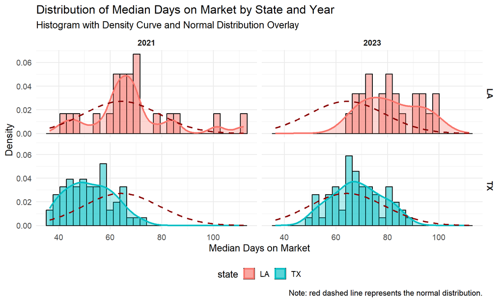

```r
FREDLARTXLA <- read_parquet("proc_data/FREDLARTXLA.parquet")
# Quick checks
#names(FREDLARTXLA)
#head(FREDLARTXLA)
#table(FREDLARTXLA$state)
#table(FREDLARTXLA$year)

# Select only records with valid MEDAONMACOUNTY values
palette_colors <- c("#E64B35", "#4DBBD5", "#00A087", "#3C5488")

# Select only records with valid MEDAONMACOUNTY values
q18a_data <- FREDLARTXLA %>%
  filter(!is.na(MEDAONMACOUNTY))

# Create histogram + density + normal overlay
ggplot(q18a_data, aes(x = MEDAONMACOUNTY, fill = state)) +
  geom_histogram(aes(y = ..density..),
                 bins = 30, alpha = 0.5, color = "black") +
  geom_density(aes(color = state, fill = state),
               size = 1.2,
               alpha = 0.3) +   # <<< transparency added
  facet_grid(state ~ year) +
  stat_function(
    fun = dnorm,
    args = list(
      mean = mean(q18a_data$MEDAONMACOUNTY, na.rm = TRUE),
      sd   = sd(q18a_data$MEDAONMACOUNTY, na.rm = TRUE)
    ),
    color = "darkred",
    size  = 1,
    linetype = "dashed"
  ) +
  labs(
    title = "Distribution of Median Days on Market by State and Year",
    subtitle = "Histogram with Density Curve and Normal Distribution Overlay",
    x = "Median Days on Market",
    y = "Density",
    caption="Note: red dashed line represents the normal distribution."
  ) +
  theme_minimal(base_size = 14) +
  theme(
    legend.position = "bottom",
    strip.text = element_text(face = "bold")
  )
```

*b. Provide a grouped bar chart of percentage loan refinancing by state and year with “Home ownership bin” as the grouping variable.* i. Make sure the groups are labeled clearly and colors are used to distinguish between groups. ii. Label the top of the bars with the values.

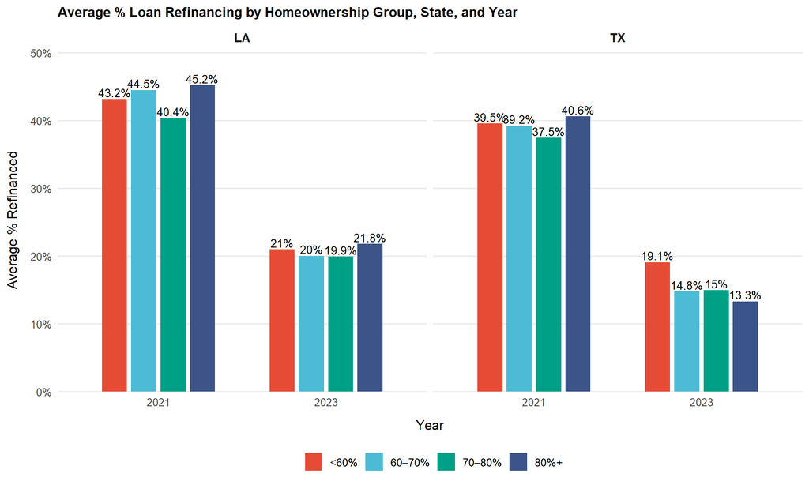

```r
# Create homeownership bins
fred_data_binned <- FREDLARTXLA %>%
  filter(
    !is.na(percentage_loan_refinancing),
    !is.na(HOWNRATEACS)
  ) %>%
  mutate(
    home_bin = case_when(
      HOWNRATEACS < 60 ~ "<60%",
      HOWNRATEACS >= 60 & HOWNRATEACS < 70 ~ "60–70%",
      HOWNRATEACS >= 70 & HOWNRATEACS < 80 ~ "70–80%",
      HOWNRATEACS >= 80 ~ "80%+",
      TRUE ~ NA_character_
    ),
    home_bin = factor(
      home_bin,
      levels = c("<60%", "60–70%", "70–80%", "80%+")
    )
  )

# Aggregate data: average % loan refinancing
q18b_summary <- fred_data_binned %>%
  group_by(state, year, home_bin) %>%
  summarise(
    avg_refi = mean(percentage_loan_refinancing, na.rm = TRUE),
    .groups = "drop"
  ) %>%
  rename(State = state)

# Color palette to mirror the first plot's style
home_bins <- sort(unique(q18b_summary$home_bin))
palette_colors <- c("#E64B35", "#4DBBD5", "#00A087", "#3C5488")
palette_colors <- rep(palette_colors, length.out = length(home_bins))
home_colors <- setNames(palette_colors, home_bins)

# Graph (styled like your loan plot)
ggplot(
  q18b_summary,
  aes(
    x   = factor(year),
    y   = avg_refi,
    fill = home_bin
  )
) +
  geom_col(
    position = position_dodge(width = 0.7),
    width    = 0.6
  ) +
  geom_text(
    aes(label = paste0(round(avg_refi, 1), "%")),
    position = position_dodge(width = 0.7),
    vjust    = -0.25,
    size     = 3.5
  ) +

  facet_wrap(~ State, nrow = 1) +
  scale_fill_manual(
    values = home_colors,
    name   = ""
  ) +

  scale_y_continuous(
    labels = function(x) paste0(x, "%"),
    expand = expansion(mult = c(0, 0.12))
  ) +

  labs(
    title = "Average % Loan Refinancing by Homeownership Group, State, and Year",
    x     = "Year",
    y     = "Average % Refinanced"
  ) +

  theme_minimal(base_size = 12) +
  theme(
    plot.title   = element_text(face = "bold", size = 12),
    plot.caption = element_text(size = 10, hjust = 0, margin = margin(t = 10)),

    axis.text.x  = element_text(angle = 0, hjust = 0.5, vjust = 1),
    axis.title.x = element_text(margin = margin(t = 10)),
    axis.title.y = element_text(margin = margin(r = 10)),

    panel.grid.major.x = element_blank(),
    panel.grid.minor   = element_blank(),

    strip.text = element_text(face = "bold", size = 11),

    legend.position = "bottom",
    legend.title    = element_text(face = "bold"),
    legend.box      = "horizontal"
  ) +
  guides(fill = guide_legend(ncol = 4))
```

# 12 Q19. Subset the data to only the first year of data. Calculate the following correlation matrix by state and year:

*a. Take the log of all of the variables you have added (i.e. Equifax Subprime Credit, median price, population, poverty,…).*

```r
# Select numeric variables to log (exclude identifiers)
vars_to_log <- FREDLARTXLA %>%
  dplyr::select(-county_code,-state,-year,-commute_time_bins) %>%
  dplyr::select(where(is.numeric)) %>%
  names()
# Create logged versions using log1p (log(1 + x))
FREDLARTXLA_l <- FREDLARTXLA %>%
  dplyr::mutate(
    dplyr::across(dplyr::all_of(vars_to_log), ~ log1p(.x), .names = "log_{.col}"))

FREDLARTXLA_l <- FREDLARTXLA_l %>%
  dplyr::rename(
    log_equifax_subprime_q4              = log_EQFXSUBPRIME,
    log_median_days_on_market            = log_MEDAONMACOUNTY,
    log_homeownership_rate_acs5          = log_HOWNRATEACS,
    log_poverty_rate                     = log_PPAAWY,
    log_mean_commute_time                = log_commute_time_mean,
    log_crime_rate_fbitc                 = log_FBITC,
    log_hs_grad_rate_acs5                = log_HC01ESTVC16,
    log_snap_beneficiaries               = log_SNAPBR,
    log_population_county_thousands      = log_POPULATION
  )

log_vars <- c(
  "log_equifax_subprime_q4",
  "log_median_days_on_market",
  "log_homeownership_rate_acs5",
  "log_poverty_rate",
  "log_mean_commute_time",
  "log_crime_rate_fbitc",
  "log_hs_grad_rate_acs5",
  "log_snap_beneficiaries",
  "log_population_county_thousands"
)

ds_2021 <- FREDLARTXLA_l %>%
  filter(year == 2021)

ds_2023 <- FREDLARTXLA_l %>%
  filter(year == 2023)

FREDLARTXLA_l_yrs <- list(
  "2021" = ds_2021,
  "2023" = ds_2023
)
```

*b. Correlation matrix comparing all of the variables you have added to loan amount.* i. Exclude all variables that use/are derived from loan amount in the calculation of the variable (i.e. log(loan amount), (loan amount)/population, …) ii. Please round all the correlations to two decimal places in the software. iii. If your correlation is above 85%, then you need to reconsider part (i). It is unlikely the variable you have chosen is not directly related to loan amount.

[figure not shown]

```r
# Compute correlation matrix
corr_matrix <- ds_2021 %>%
  select(all_of(log_vars)) %>%
  cor(use = "pairwise.complete.obs") %>%
  round(2)

  # ----------------------------------------
  # Add readable labels
  # ----------------------------------------
  label_map <- c(
    log_equifax_subprime_q4         = "Log Equifax Subprime Credit Data (Q4)",
    log_median_days_on_market       = "Log Market Hotness: Median Days on Market (EOY M12)",
    log_homeownership_rate_acs5     = "Log Homeownership Rate (5-year estimate)",
    log_poverty_rate                = "Log % of People of All Ages in Poverty",
    log_mean_commute_time           = "Log Mean Commuting Time for Workers",
    log_crime_rate_fbitc            = "Log Violent & Property Crime Offenses Known",
    log_hs_grad_rate_acs5           = "Log High School Graduate or Higher (5-year estimate)",
    log_snap_beneficiaries          = "Log SNAP Benefits Recipients",
    log_population_county_thousands = "Log County Population (Thousands)"
  )

colnames(corr_matrix) <- label_map[colnames(corr_matrix)]
rownames(corr_matrix) <- label_map[rownames(corr_matrix)]

# ---- Visualize correlation plot ----
par(family = "sans", cex = 1)

corrplot(
  corr_matrix,
  method = "color",
  type = "upper",
  tl.col = "black",
  tl.srt = 45,
  tl.cex = 0.5,
  addCoef.col = "black",
  number.cex = 0.5,
  mar = c(0, 0, 3, 0)
)
title(
  main = "Correlation Matrix for Year 2021",
  cex.main = 1,
  font.main = 2
)
```

*High-correlations >0.85*

```r
# ---- Compute high correlations ----
high_corr_pairs <- corr_matrix %>%
  as.data.frame() %>%
  rownames_to_column("var1") %>%
  pivot_longer(cols = -var1,
               names_to = "var2",
               values_to = "corr") %>%
  filter(var1 < var2) %>%       # avoid duplicates
  filter(abs(corr) > 0.85)      # threshold

# ---- Print high correlations ----
if (nrow(high_corr_pairs) == 0) {
  cat("  None found.\n")
} else {
    print(high_corr_pairs)
}
```

```
## # A tibble: 1 × 3
##   var1                              var2                          corr
##   <chr>                             <chr>                        <dbl>
## 1 Log County Population (Thousands) Log SNAP Benefits Recipients  0.95
```

*c. Correlation matrix comparing all of the logged variables to loan amount.* i. Please round all the correlations to two decimal places in the software.

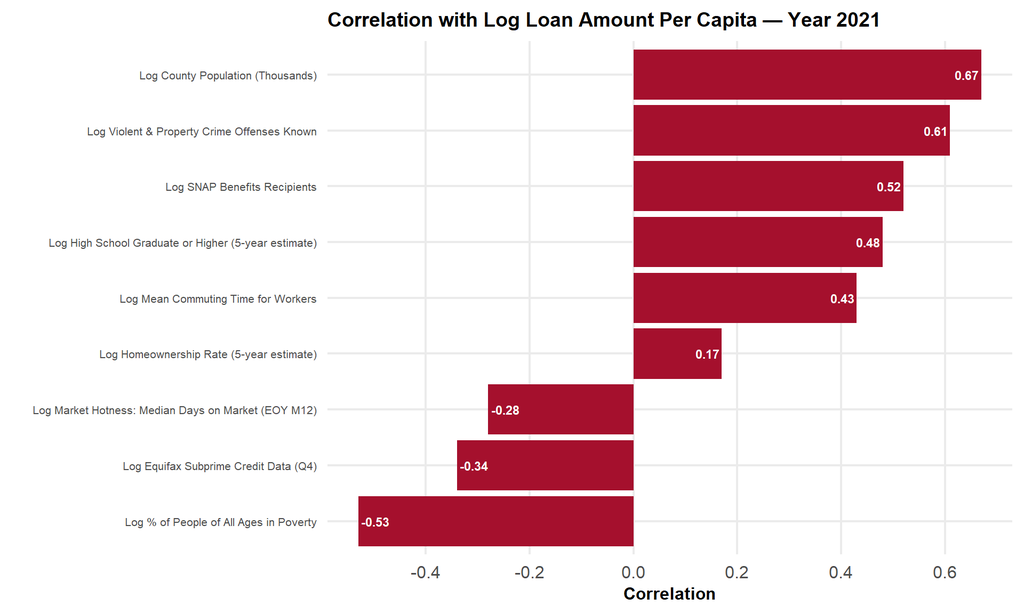

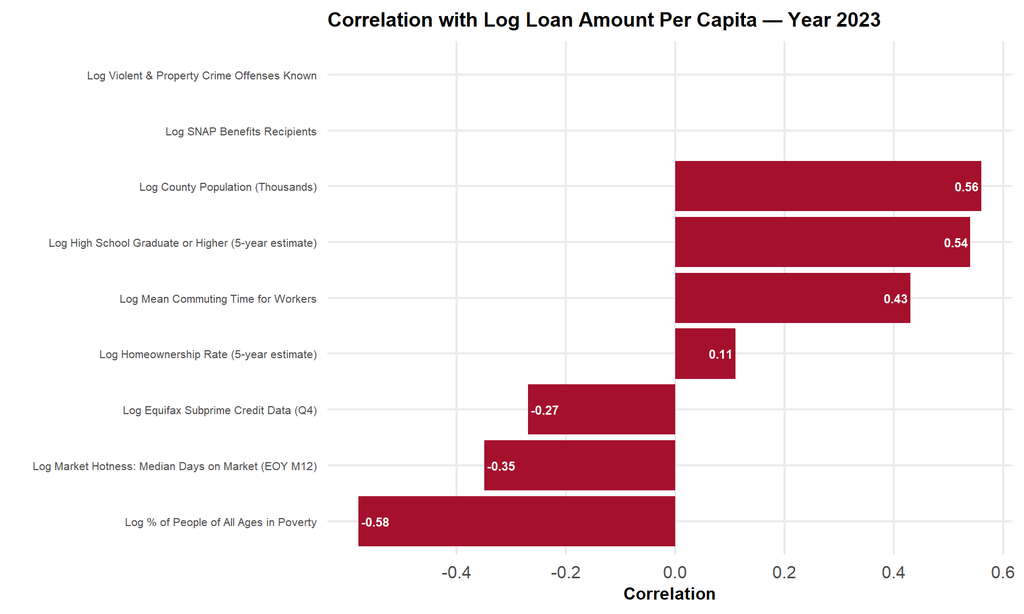

```r
vars_for_corr <- c(log_vars, "log_loan_amount_percapita")
years_to_run <- c(2021, 2023)

for (yr in years_to_run) {

  df <- FREDLARTXLA_l_yrs[[as.character(yr)]]
  # Build correlation matrix
  corr_matrix <- df %>%
    select(all_of(vars_for_corr)) %>%
    cor(use = "pairwise.complete.obs")

  corr_matrix_rounded <- round(corr_matrix, 2)

  # Print matrix
  #print(corr_matrix_rounded)

  # ----------------------------------------
  # Extract correlations with log_loan_amount_percapita
  # ----------------------------------------
  corr_vec <- corr_matrix_rounded[, "log_loan_amount_percapita"]

  corr_df <- data.frame(
    variable = names(corr_vec),
    correlation = as.numeric(corr_vec)
  )

  # Remove the variable itself
  corr_df <- corr_df %>%
    filter(variable != "log_loan_amount_percapita") %>%
    arrange(desc(correlation))

  corr_df <- corr_df %>%
    mutate(
      variable_label = label_map[variable],
      label_hjust    = ifelse(correlation > 0, 1.1, -0.1)
    )

  # ----------------------------------------
  # Barplot
  # ----------------------------------------
  print(
    ggplot(corr_df, aes(x = reorder(variable_label, correlation),
                        y = correlation)) +
      geom_col(fill = "#A5102D") +
      geom_text(
        aes(label = round(correlation, 2), hjust = label_hjust),
        color = "white",
        size = 3,
        fontface = "bold"
      ) +
      coord_flip() +
      scale_y_continuous(breaks = seq(-0.4, 1, by = 0.2)) +
      labs(
        title = paste("Correlation with Log Loan Amount Per Capita — Year", yr),
        x = "",
        y = "Correlation"
      ) +
      theme_minimal(base_size = 16) +
      theme(
        plot.title = element_text(face = "bold", size = 14),
        axis.title.x = element_text(size = 12, face = "bold"),
        axis.title.y = element_text(size = 12, face = "bold"),
        axis.text.x  = element_text(size = 12),
        axis.text.y  = element_text(size = 8),
        panel.grid.minor = element_blank()
      )
  )
}
```

# 13 Q20. Plot a scatterplot of the strongest correlation with loan value you achieve in the previous question placing the average loan value on the y axis and the variable of your choice on the X axis.

*a. Does the graph support a linear relationship between the two variables?* Yes, the graphs support the presence of linear relationships.

In the 2021 scatterplot of Loan Amount Per Capita vs. Violent & Property Crime Offenses Known, the points show an upward trend, and the fitted regression line captures a clear positive linear association: as the log of crime offenses increases, the log of loan amount per capita also tends to increase.

In the scatterplots of Loan Amount Per Capita vs. Log of People of All Ages in Poverty (2021 & 2023), both years exhibit a downward trend, with fitted regression lines showing consistent negative slopes. This indicates a negative linear relationship: counties with higher poverty levels tend to have lower loan amounts per capita. Although 2021 and 2023 differ slightly in magnitude and slope, the linear pattern is visible in both.

Overall, the scatterplots show trends that align well with straight-line patterns, and the fitted regression lines reflect this. Therefore, the plots provide visual evidence supporting linear relationships between the variables in both years.

*b. Title and label your graph appropriately.* *c. Either do years separately in two side by side graphs or place all observations in a single plot and use either color or shapes to separate the two groups.*

## 13.1 Scatterplot Loan Amount Per Capita and Violent & Crime Offensese Known (2021)

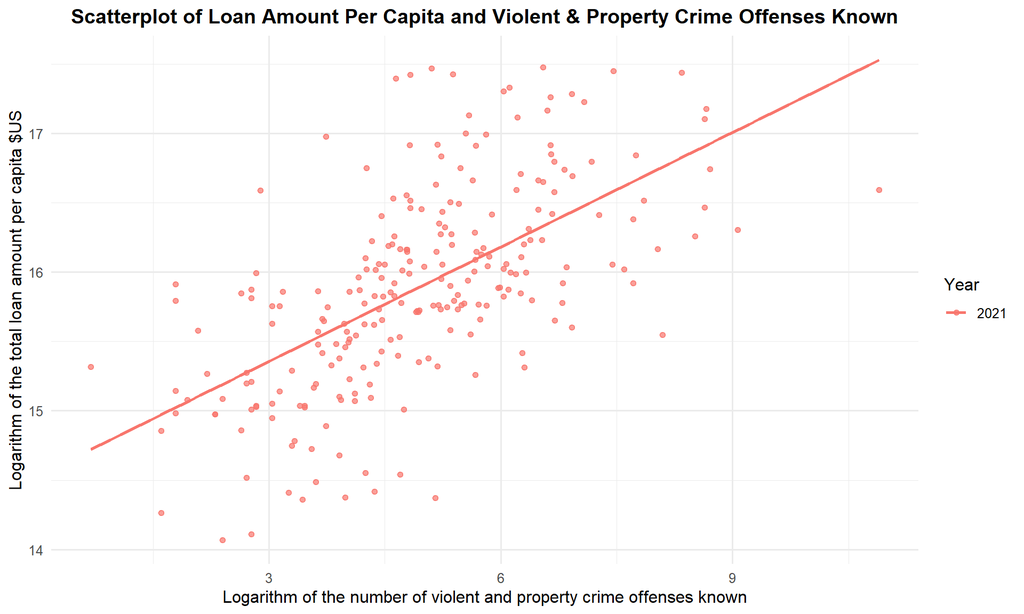

```r
#Plots
FRED_clean <- FREDLARTXLA_l %>%
  filter(
    !is.na(log_loan_amount_percapita),
    !is.na(log_crime_rate_fbitc),
    log_loan_amount_percapita > 0,
    log_crime_rate_fbitc > 0
  )

ggplot(
  FRED_clean,
  aes(x = log_crime_rate_fbitc,
      y = log_loan_amount_percapita,
      color = as.factor(year))
) +
  geom_point(alpha = 0.7) +
  geom_smooth(method = "lm", se = FALSE, linewidth = 1) +
  labs(
    title = "Scatterplot of Loan Amount Per Capita and Violent & Property Crime Offenses Known",
    x = "Logarithm of the number of violent and property crime offenses known",
    y = "Logarithm of the total loan amount per capita $US",
    color = "Year"
  ) +
  theme_minimal(base_size = 12) +
  theme(
    plot.title = element_text(hjust = 0.5, face = "bold"),
    legend.position = "right"
  )
```

## 13.2 Scatterplot Loan Amount Per Capita and Log of People of All Ages in Poverty (2021 & 2023)

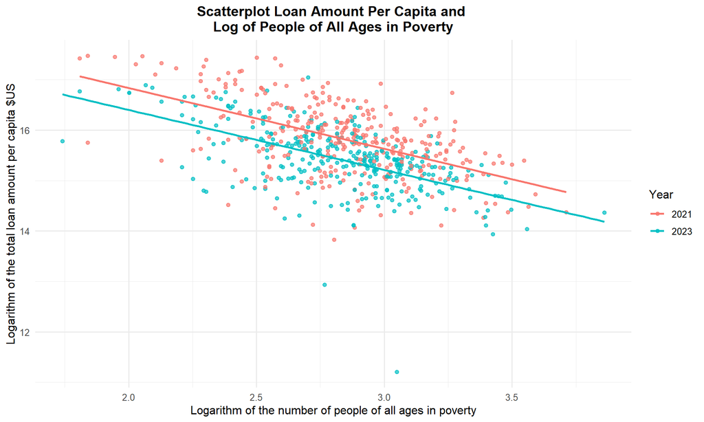

```r
FRED_clean2 <- FREDLARTXLA_l %>%
  filter(
    !is.na(log_loan_amount_percapita),
    !is.na(log_poverty_rate),
    log_loan_amount_percapita > 0,
    log_poverty_rate > 0
  )

ggplot(
  FRED_clean2,
  aes(
    x = log_poverty_rate,
    y = log_loan_amount_percapita,
    color = as.factor(year)
  )
) +
  geom_point(alpha = 0.7) +
  geom_smooth(method = "lm", se = FALSE, linewidth = 1) +
  labs(
    title = "Scatterplot Loan Amount Per Capita and \nLog of People of All Ages in Poverty",
    x = "Logarithm of the number of people of all ages in poverty",
    y = "Logarithm of the total loan amount per capita $US",
    color = "Year"
  ) +
  theme_minimal(base_size = 12) +
  theme(
    plot.title = element_text(hjust = 0.5, face = "bold"),
    legend.position = "right"
  )
```

# 14 Q21. Make a grouped boxplot or violin plot demonstrating the distribution of subprime mortgages by the home ownership bin variable made earlier. Each year should be a different color and the graph should have a clear legend. Use this plot to identify any extreme outlying counties.

##Box Plot

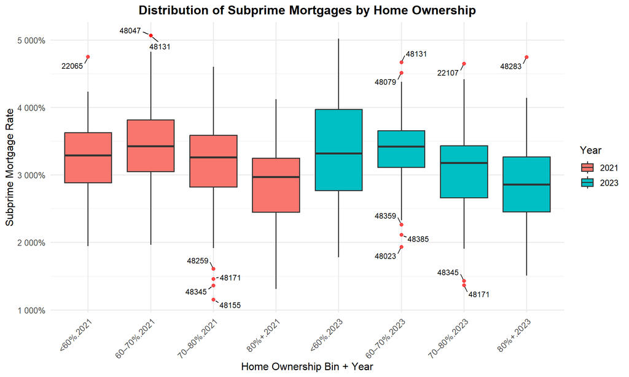

```r
#calculate outliers
outliers <- fred_data_binned %>%
  group_by(home_bin, year) %>%
  mutate(
    Q1 = quantile(EQFXSUBPRIME, 0.25, na.rm = TRUE),
    Q3 = quantile(EQFXSUBPRIME, 0.75, na.rm = TRUE),
    IQR = Q3 - Q1,
    lower = Q1 - 1.5 * IQR,
    upper = Q3 + 1.5 * IQR
  ) %>%
  filter(EQFXSUBPRIME < lower | EQFXSUBPRIME > upper) %>%
  ungroup

#Box Plot, outliers labeled by county code
ggplot(fred_data_binned, aes(x = interaction(home_bin, year), y = EQFXSUBPRIME, fill = as.factor(year))) +
  geom_boxplot(outlier.color = "red", outlier.alpha = 0.7) +
  geom_text_repel(
    data = outliers,
    aes(x = interaction(home_bin, year),
        y = EQFXSUBPRIME,
        label = county_code),
    color = "black",
    size = 3,
    max.overlaps = Inf,
    box.padding = 0.4,
    point.padding = 0.3,
    min.segment.length = 0
  ) +
  labs(
    title = "Distribution of Subprime Mortgages by Home Ownership",
    x = "Home Ownership Bin + Year",
    y = "Subprime Mortgage Rate",
    fill = "Year" )  +
  scale_y_continuous(labels = scales::percent_format())  +
  theme_minimal(base_size = 12) +
  theme(
    plot.title = element_text(hjust = 0.5, face = "bold"),
    legend.position = "right",
    axis.text.x = element_text(angle = 45, hjust = 1)
    )
```

##Violin Plot

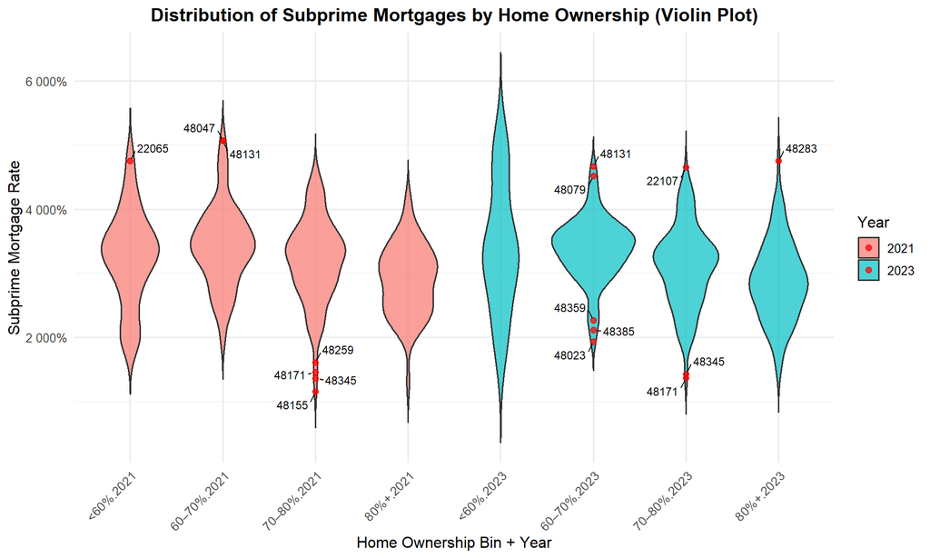

```r
#Violin Plot, outliers labeled by county code
ggplot(fred_data_binned, aes(x = interaction(home_bin, year), y = EQFXSUBPRIME, fill = as.factor(year))) +
  geom_violin(trim = FALSE, alpha = 0.7) +
  geom_point(
    data = outliers,
    aes(x = interaction(home_bin, year),
        y = EQFXSUBPRIME),
    color = "red",
    alpha = 0.7,
    size = 2 ) +
  geom_text_repel(
    data = outliers,
    aes(x = interaction(home_bin, year),
        y = EQFXSUBPRIME,
        label = county_code),
    color = "black",
    size = 3,
    max.overlaps = Inf,
    box.padding = 0.4,
    point.padding = 0.3,
    min.segment.length = 0) +
  labs(
    title = "Distribution of Subprime Mortgages by Home Ownership (Violin Plot)",
    x = "Home Ownership Bin + Year",
    y = "Subprime Mortgage Rate",
    fill = "Year"
  )  +
  scale_y_continuous(labels = scales::percent_format())  +
  theme_minimal(base_size = 12) +
  theme(
    plot.title = element_text(hjust = 0.5, face = "bold"),
    legend.position = "right",
    axis.text.x = element_text(angle = 45, hjust = 1)
    )
```

The box plot provided a lot of useful information, but it hides some of the changes in the distribution within the interquartile range. The violin plot fills this gap by highlighting important shifts in the distribution of subprime mortgages by homeownership between 2021 and 2023. For homeownership below 60%, the distribution becomes flatter, while for the 60–70% group it becomes more concentrated. For the 70–80% homeownership group, subprime rates remain relatively similar across the two years. In contrast, for homeownership of 80% or more, the concentration of subprime mortgage rates shifts to lower values (from two concentrated regions to a single one around 30%).